# Método de Agrupamento para análise de estabilidade e reprodutibilidade em radiômica

Gabriel Bertolini | Orientador: Prof. Dr. Cristiano Lima Hackmann, Departamento de Estatística, UFRGS

09 de outubro de 2026

# 1. Apresentação

## 1.1 Contexto: a radiômica e sua etapa estatística

A radiômica pode ser definida como o processo que converte exames de imagem médica, tradicionalmente interpretados de forma visual, em dados quantitativos de alta dimensionalidade capazes de revelar padrões associados à biologia tumoral (Gillies, Kinahan e Hricak, 2016). Trata-se de abordagem não invasiva, que reaproveita imagens já obtidas na rotina clínica e pode ser repetida ao longo do tempo, permitindo monitoramento sem exames adicionais (Lambin et al., 2017).

A chamada hipótese radiômica sustenta que a variação espacial de intensidade, textura e forma nos tumores reflete processos subjacentes como proliferação, necrose e angiogênese, de modo que descritores quantitativos extraídos das imagens carregariam informação relevante para diagnóstico, prognóstico e predição terapêutica (Lambin et al., 2012).

O fluxo analítico radiômico é tipicamente descrito em etapas sucessivas: aquisição das imagens, padronização, segmentação da região de interesse, extração dos descritores quantitativos e, por fim, análise estatística (Rizzo et al., 2018; Scapicchio et al., 2021). Este trabalho tem foco na última etapa. Os descritores extraídos abrangem categorias complementares que descrevem diferentes dimensões da lesão: estatísticas de primeira ordem, que resumem a distribuição de intensidades; medidas de forma e tamanho, que capturam geometria e extensão; e famílias de textura, que quantificam padrões de heterogeneidade interna (van Timmeren et al., 2020).

## 1.2 Problemas de Inconsistência e Instabilidade

A etapa final do fluxo radiômico enfrenta um conjunto de desafios amplamente documentados. Três condições, simultaneamente presentes na maior parte dos estudos da área, favorecem a instabilidade dos resultados: **número reduzido de casos**, **grande volume de variáveis** e **alta correlação entre elas** (Gillies et al., 2016; Park et al., 2019). Sob essas condições, múltiplos subconjuntos de descritores podem apresentar desempenho preditivo equivalente, gerando modelos alternativos igualmente defensáveis mas pouco consistentes entre repetições (Khaire e Dhanalakshmi, 2019).

A literatura documenta ainda um conjunto recorrente de problemas de prática: ausência de disponibilização de código e dados (Akinci D’Antonoli et al., 2024; Liu et al., 2019); normalização aplicada fora das dobras da validação cruzada, que introduz vazamento de informação e infla artificialmente tanto o desempenho quanto a estabilidade aparente (Castaldo et al., 2020; Demircioglu, 2021; Apicella et al., 2025); documentação insuficiente de elementos essenciais como semente aleatória, número de partições e grade de valores do parâmetro de ajuste (Zhao, 2021; Park et al., 2020); e, sobretudo, ausência de avaliação formal da estabilidade da seleção de variáveis (Perniciano et al., 2025).

As consequências são conhecidas: variabilidade elevada entre estudos, seleções inconsistentes, baixa interpretabilidade e dificuldade de generalização, que em conjunto constituem barreiras à adoção clínica de modelos radiômicos (Park et al., 2020; Zwanenburg et al., 2020).

Este trabalho atende diretamente ao último desses pontos e adota como premissa a recomendação, sustentada por Nogueira, Sechidis e Brown (2018) e Demircioglu (2021), de que a estabilidade deve ser avaliada de forma sistemática, sob múltiplas sementes e particionamentos, com todo o pré-processamento restrito ao conjunto de treino de cada dobra.

## 1.3 Delineamento em dois eixos

O objetivo do estudo é avaliar a confiabilidade da etapa estatística do fluxo radiômico em dois eixos distintos e complementares:

| Eixo | O que varia | Objeto de avaliação | Supervisionado? | Método |
| --- | --- | --- | --- | --- |
| **Reprodutibilidade** | o **método** (distância, ligação, corte) | a partição do espaço de variáveis | Não Supervisionado | Agrupamento Hierárquico |
| **Estabilidade** | os **dados** (partições de validação cruzada) | o conjunto de variáveis selecionadas | Supervisionado | Random Forest |

A distinção é deliberada e retoma as duas definições correntes na literatura. Segundo Nogueira, Sechidis e Brown (2018), **estabilidade** significa que pequenas mudanças nos dados não devem alterar o subconjunto de variáveis selecionado; **reprodutibilidade**, por sua vez, exige que um resultado possa ser obtido novamente a partir das informações fornecidas, o que envolve as decisões analíticas e não apenas os dados. A estabilidade mantém o procedimento fixo e verifica se ele responde a mesma coisa quando os dados mudam um pouco. A reprodutibilidade mantém os dados fixos e verifica se decisões analíticas defensáveis, mas raramente relatadas, levariam a descrições diferentes do mesmo conjunto de dados. O **agrupamento hierárquico** das variáveis é a ponte entre os dois: é o objeto cuja reprodutibilidade se avalia e, ao mesmo tempo, a unidade em que a estabilidade é remensurada.

## 1.4 A hipótese central e sua fundamentação

A alta correlação entre descritores radiômicos tem consequência específica sobre os métodos de seleção. Tolosi e Lengauer (2011) demonstraram que o ordenamento de variáveis por importância torna-se não confiável sob colinearidade elevada, e métodos baseados em penalização L1, como o LASSO, tendem a escolher arbitrariamente uma variável entre várias fortemente correlacionadas (Nogueira et al., 2018; Hastie, Tibshirani e Friedman, 2009).

Um desenvolvimento posterior do mesmo grupo formalizou a consequência dessa observação para a mensuração: Sechidis et al. (2020) demonstraram que as métricas usuais de estabilidade subestimam sistematicamente a consistência verdadeira na presença de correlação forte entre preditores, produzindo um retrato excessivamente pessimista do procedimento de seleção. O argumento é direto: se duas variáveis carregam informações praticamente equivalentes, escolher ora uma ora outra não constitui inconsistência substantiva, ainda que seja contabilizado como tal por qualquer medida de sobreposição entre conjuntos.

Daí decorre a hipótese central aqui investigada: mensurada na unidade do grupo de descritores mutuamente redundantes, e não na do descritor individual, a seleção deve revelar-se substancialmente mais consistente sem que nada no modelo ajustado tenha sido alterado.

Cabe registrar que essa investigação responde diretamente à direção futura apontada por Peitz (2025), que ao estudar estabilidade e reprodutibilidade em radiômica de câncer de mama concluiu sugerindo avaliar a estabilidade em nível de grupos de variáveis, sob o argumento de que a instabilidade aparente em nível individual pode ocultar estabilidade maior quando observada em nível de grupos. O presente trabalho implementa essa avaliação, em outro sítio tumoral e com método de seleção distinto.

Verificar a hipótese exige, porém, que o agrupamento utilizado como unidade de mensuração seja ele próprio confiável, o que motiva o eixo de reprodutibilidade descrito acima.

## 1.5 O protocolo de contraste

Uma terceira dimensão atravessa ambos os eixos: o protocolo de aquisição. Parte dos exames foi realizada com contraste endovenoso e parte sem. Como o contraste altera diretamente a atenuação dos tecidos, descritores de intensidade extraídos sob os dois protocolos não são, a rigor, comensuráveis. Variabilidade técnica dessa natureza é reconhecidamente uma das principais barreiras à generalização de modelos radiômicos entre instituições (Traverso et al., 2018; van Velden et al., 2016), o que exige tratamento explícito e não apenas menção entre as limitações. Esta é a principal fonte de variabilidade técnica do banco e é tratada antes de qualquer modelagem radiômica: os descritores alterados pelo contraste são identificados pelo delta de Cliff e removidos (Seções 6 e 7). O protocolo é também incorporado ao desenho amostral de todas as análises subsequentes.

## 1.6 O desfecho como tarefa-referência

A discriminação entre adenocarcinoma pulmonar e colorretal funciona como tarefa-referência. A seleção supervisionada exige um desfecho para operar: sem rótulo não há noção de importância e, portanto, não há conjunto selecionado cuja estabilidade se possa medir. Um desfecho com sinal detectável é condição metodológica necessária, pois, se a capacidade discriminativa fosse nula, qualquer instabilidade teria explicação trivial. Há também plausibilidade clínica indireta na diferenciação entre adenocarcinoma pulmonar primário e metástase pulmonar de origem colorretal, cenário em que a decisão frequentemente demanda confirmação histológica por meio de procedimento invasivo e altera a conduta terapêutica (Lee, Jeong e Kim, 2021).

## 1.7 Um modelo de referência clínico

Na prática clínica, lesões pulmonares são caracterizadas principalmente pelo **tamanho** e pela **forma**. O diâmetro e a morfologia da borda (lisa, lobulada ou espiculada) são critérios centrais na avaliação de nódulos pulmonares (Snoeckx et al., 2018) e compõem os modelos de risco mais usados na rotina, como os da Mayo Clinic e de Brock, ambos regressões logísticas que combinam o tamanho do nódulo com a presença de espiculação (Swensen et al., 1997; McWilliams et al., 2013). Na distinção entre adenocarcinoma pulmonar primário e metástase pulmonar de câncer colorretal, a forma tem papel de destaque: tumores primários tendem a apresentar bordas irregulares ou espiculadas, enquanto metástases tendem a ser arredondadas e de contorno liso (Lee, Jeong e Kim, 2021).

Entre os descritores radiômicos, a **esfericidade** é a medida que melhor traduz essa avaliação de forma: ela compara a superfície da lesão com a de uma esfera de mesmo volume e diminui à medida que a borda se torna irregular, acompanhando o grau de espiculação (Limkin et al., 2019). Por construção, não depende do tamanho da lesão; o tamanho permanece representado na análise radiômica, que inclui descritores fortemente associados ao volume.

Por isso, o estudo parte de um **modelo base**: uma regressão logística com a esfericidade como única variável, simples e facilmente interpretável pela clínica. Os modelos radiômicos são avaliados contra essa referência, o que permite responder não apenas se são estáveis e reprodutíveis, mas também se acrescentam informação ao que a avaliação da forma já oferece.

## 1.8 Estratégia da análise

| Etapa | Pergunta | Seção |
| --- | --- | --- |
| **Modelo base** | Quanto a irregularidade da borda, medida pela esfericidade, discrimina os diagnósticos numa regressão logística simples? | 5 |
| **Controle do contraste** | Quais descritores não são alterados pelo protocolo de contraste em nenhum dos diagnósticos? | 6 e 7 |
| **Seleção** | Quais desses descritores o Random Forest escolhe com mais frequência? | 8 |
| **Agrupamento e reprodutibilidade** | Os descritores formam grupos redundantes? Essa estrutura se reproduz com outros pacientes e outras decisões de método? | 9 a 11 |
| **Estabilidade** | A seleção é mais consistente quando lida no nível de cluster, descontado o acaso? | 12 |
| **Comparação** | Os modelos radiômicos superam o modelo base ou acrescentam informação a ele? | 13 |

Os métodos estatísticos de cada etapa estão descritos na Seção 4.

# 2. Pacotes e parâmetros

```r
library(readr)        # leitura de CSV
library(readxl)       # leitura de Excel
library(dplyr)        # manipulação dos dados
library(ggplot2)      # gráficos
library(knitr)        # tabelas
library(kableExtra)   # formatação de tabelas
library(randomForest) # Random Forest
library(pROC)         # AUC
library(caret)        # partições estratificadas
library(pheatmap)     # mapas de calor
library(RColorBrewer) # paletas de cores
library(cluster)      # silhueta
```

```r
CAMINHO <- "C:/Users/gabri/OneDrive/Documentos/TCC/bd_rad_clinico.csv"

# Lapidação
LIM_DESPREZIVEL <- 0.147   # |delta de Cliff| < 0,147: efeito desprezível (Romano et al., 2006)

# Validação cruzada e Random Forest
N_SEEDS   <- 10            # repetições da validação cruzada
N_FOLDS   <- 5             # folds externos
N_FOLDS_I <- 3             # folds internos (escolha do mtry)
NTREE     <- 500           # árvores no ajuste final
NTREE_TUN <- 300           # árvores na escolha do mtry

# Seleção
K_GRID <- c(3, 5, 7)       # tamanhos do conjunto selecionado
TOP_K  <- 5                # k de referência

# Agrupamento
CORTE  <- 0.20             # corte do dendrograma: d = 1 - |rho|, isto é, |rho| >= 0,80
B_BOOT <- 300              # reamostragens nas análises de reprodutibilidade

# Estabilidade da seleção
B_ACASO      <- 2000       # sorteios para a linha de base do acaso (Jaccard)
B_ACASO_PHI  <- 200        # sorteios para a linha de base do acaso (Phi)
B_PERM       <- 200        # permutações do diagnóstico
N_SEEDS_PERM <- 5          # sementes por permutação

SEMENTE <- 42
set.seed(SEMENTE)
```

> **Sobre o tamanho do conjunto selecionado.** Com cerca de 18 descritores lapidados, selecionar os 10 mais importantes de cada ajuste incluiria mais da metade do conjunto, e qualquer descritor razoável apareceria com frequência alta. Por isso, adota-se $k = 5$ como referência e avaliam-se também $k = 3$ e $k = 7$.

# 3. Dados

## 3.1 Importação

Cada linha é um paciente; cada coluna `original_*` é um descritor radiômico calculado na imagem original, sem filtros.

```r
ler_base <- function(caminho) {
  if (grepl("\\.xlsx?$", caminho, ignore.case = TRUE)) {
    d <- readxl::read_excel(caminho)
    if (ncol(d) == 1) {  # exportação com o CSV inteiro em uma única coluna
      d <- readr::read_csv(paste(c(names(d), d[[1]]), collapse = "\n"),
                           show_col_types = FALSE)
    }
    d
  } else {
    readr::read_csv(caminho, show_col_types = FALSE)
  }
}

bruto <- ler_base(CAMINHO)
feat_todas <- names(bruto)[grepl("^original_", names(bruto))]

cat("Dimensões da planilha:", nrow(bruto), "linhas x", ncol(bruto), "colunas\n")
```

```
## Dimensões da planilha: 97 linhas x 109 colunas
```

```r
cat("Descritores radiômicos:", length(feat_todas), "\n")
```

```
## Descritores radiômicos: 105
```

```r
cat("Variáveis não radiômicas:",
    paste(setdiff(names(bruto), feat_todas), collapse = ", "), "\n")
```

```
## Variáveis não radiômicas: ...1, id_table, diagnostico, contraste
```

## 3.2 Limpeza e definição das variáveis

Dois critérios de exclusão, ambos fixados antes de qualquer análise inferencial: pacientes sem extração radiômica completa e descritores constantes, que não contribuem para a matriz de correlação.

```r
falt <- apply(is.na(bruto[, feat_todas]), 1, any)
if (any(falt)) {
  id <- if ("id_table" %in% names(bruto)) bruto$id_table[falt] else which(falt)
  cat("Excluídos por radiômica ausente:", paste(id, collapse = ", "), "\n")
}
```

```
## Excluídos por radiômica ausente: Table_40
```

```r
dados <- bruto[!falt, ]

const <- feat_todas[sapply(dados[, feat_todas], function(x) length(unique(x)) <= 1)]
if (length(const) > 0) cat("Descritores constantes removidos:", paste(const, collapse = ", "), "\n")
feat <- setdiff(feat_todas, const)

# Desfecho: 1 = pulmão, 0 = colorretal.
dx <- iconv(dados$diagnostico, to = "ASCII//TRANSLIT")
y  <- as.integer(grepl("pulm", dx, ignore.case = TRUE))

# Protocolo: 1 = com contraste, 0 = sem
ctr_txt <- iconv(dados$contraste, to = "ASCII//TRANSLIT")
ct <- as.integer(grepl("^s", trimws(tolower(ctr_txt))))   # "sim" -> 1, "nao" -> 0

X <- as.matrix(dados[, feat]); storage.mode(X) <- "double"
n <- nrow(X); p <- ncol(X)

stopifnot(sum(y) > 0, sum(y) < n, !any(is.na(X)), !any(is.na(ct)))
cat("\nAmostra analítica: n =", n, "| p =", p, "| razão p/n =", round(p/n, 2), "\n")
```

```
##
## Amostra analítica: n = 96 | p = 105 | razão p/n = 1.09
```

```r
cat("Diagnóstico: pulmão", sum(y), "| colorretal:", sum(1 - y), "\n")
```

```
## Diagnóstico: pulmão 54 | colorretal: 42
```

```r
cat("Protocolo: com contraste", sum(ct), "| sem contraste:", sum(1 - ct), "\n")
```

```
## Protocolo: com contraste 56 | sem contraste: 40
```

```r
familia <- sapply(strsplit(feat, "_"), `[`, 2)

tab_cruz <- table(Protocolo = ifelse(ct == 1, "Com contraste", "Sem contraste"),
                  Diagnóstico = ifelse(y == 1, "Pulmão", "Colorretal"))
kable(addmargins(tab_cruz, FUN = list(Total = sum), quiet = TRUE), format = "html",
      caption = "Tabela 1. Protocolo de contraste por diagnóstico") %>%
  kable_styling(bootstrap_options = c("striped", "condensed"), full_width = FALSE)
```

Tabela 1. Protocolo de contraste por diagnóstico

|  | Colorretal | Pulmão | Total |
| --- | --- | --- | --- |
| Com contraste | 27 | 29 | 56 |
| Sem contraste | 15 | 25 | 40 |
| Total | 42 | 54 | 96 |

## 3.3 Descrição das variáveis

Os descritores foram extraídos com o PyRadiomics (van Griethuysen et al., 2017) na imagem original, sem filtros. Neste trabalho, **família** é a classe de descritores do PyRadiomics, identificada pelo prefixo do nome da variável. A Tabela 2 resume as famílias, e a Tabela 3 descreve cada descritor.

Tabela 2. Famílias de descritores do PyRadiomics

| Família | Nome | Descritores | Descrição |
| --- | --- | --- | --- |
| shape | Forma | 14 | Tamanho e forma tridimensional da lesão, calculados apenas pela segmentação, sem usar intensidades. |
| firstorder | Primeira ordem | 18 | Distribuição das intensidades dos voxels da lesão, sem considerar a posição de cada voxel. |
| glcm | Matriz de coocorrência de níveis de cinza | 22 | Textura pela frequência com que pares de níveis de cinza ocorrem em voxels vizinhos. |
| glrlm | Matriz de comprimento de corrida | 16 | Textura por sequências de voxels consecutivos com o mesmo nível de cinza (corridas) numa direção. |
| glszm | Matriz de tamanho de zona | 16 | Textura por regiões de voxels conectados com o mesmo nível de cinza (zonas), em qualquer direção. |
| gldm | Matriz de dependência de nível de cinza | 14 | Textura pelo número de vizinhos com intensidade semelhante à de cada voxel (dependência). |
| ngtdm | Matriz de diferença de tom de vizinhança | 5 | Textura pela diferença entre cada voxel e a média de seus vizinhos. |

**Tabela 3. Descrição de cada descritor** (clique para abrir)**

| Família | Descritor | Descrição |
| --- | --- | --- |
| shape | Elongation | Grau de alongamento (inverso) |
|  | Flatness | Grau de achatamento (inverso) |
|  | LeastAxisLength | Menor eixo do elipsoide |
|  | MajorAxisLength | Maior eixo do elipsoide |
|  | Maximum2DDiameterColumn | Maior diâmetro no plano coronal |
|  | Maximum2DDiameterRow | Maior diâmetro no plano sagital |
|  | Maximum2DDiameterSlice | Maior diâmetro no plano axial |
|  | Maximum3DDiameter | Maior diâmetro em 3D |
|  | MeshVolume | Volume calculado pela malha |
|  | MinorAxisLength | Eixo intermediário do elipsoide |
|  | Sphericity | Proximidade a uma esfera |
|  | SurfaceArea | Área da superfície da lesão |
|  | SurfaceVolumeRatio | Razão entre superfície e volume |
|  | VoxelVolume | Volume pela contagem de voxels |
| firstorder | 10Percentile | Percentil 10 das intensidades |
|  | 90Percentile | Percentil 90 das intensidades |
|  | Energy | Soma dos quadrados das intensidades |
|  | Entropy | Aleatoriedade do histograma de intensidades |
|  | InterquartileRange | Amplitude interquartil das intensidades |
|  | Kurtosis | Peso das caudas (curtose) |
|  | Maximum | Intensidade máxima |
|  | MeanAbsoluteDeviation | Desvio absoluto médio |
|  | Mean | Intensidade média |
|  | Median | Intensidade mediana |
|  | Minimum | Intensidade mínima |
|  | Range | Amplitude das intensidades |
|  | RobustMeanAbsoluteDeviation | Desvio absoluto médio robusto |
|  | RootMeanSquared | Raiz da média quadrática |
|  | Skewness | Assimetria das intensidades |
|  | TotalEnergy | Energia multiplicada pelo volume do voxel |

[output cut: 75 more lines]

> Nos descritores de textura, “nível alto” e “nível baixo” referem-se aos níveis de cinza após a discretização das intensidades. Descritores marcados como “não normalizada” dependem do número total de corridas, zonas ou voxels e, portanto, tendem a crescer com o tamanho da lesão.

# 4. Materiais e métodos

Esta seção reúne as definições, equações e testes usados nas análises. A implementação de cada procedimento aparece no código da seção em que ele é aplicado.

## 4.1 Notação

São $n$ pacientes, indexados por $i$, com desfecho $y_i = 1$ para adenocarcinoma pulmonar e $y_i = 0$ para colorretal, e $p$ descritores radiômicos. O protocolo de aquisição é indicado por $c_i = 1$ (com contraste) ou $c_i = 0$ (sem contraste).

## 4.2 Regressão logística do modelo base

O modelo base relaciona a probabilidade de a lesão ser pulmonar à esfericidade $e_i$ (Seção 5):

$$\log\left(\frac{\pi_i}{1 - \pi_i}\right)
= \beta_0 + \beta_1 e_i, \qquad \pi_i = P(y_i = 1 \mid
e_i).$$

Os coeficientes são estimados por máxima verossimilhança. Como a esfericidade varia entre 0 e 1, o efeito é expresso como a razão de chances para uma **redução de 0,1** na esfericidade,

$$\text{RC}_{0,1} =
\exp(-0{,}1\,\beta_1),$$

com intervalo de confiança de 95 % obtido pela transformação do intervalo de Wald de $\beta_1$. Para verificar a influência do protocolo, ajusta-se também o modelo com $c_i$ e com a interação $e_i \times c_i$.

## 4.3 Validação cruzada repetida e AUC

Todos os modelos são avaliados por validação cruzada com $K = 5$ folds, repetida $R = 10$ vezes com sementes diferentes. Os folds são estratificados pela combinação de diagnóstico e protocolo, de modo que cada fold preserve a proporção dos quatro grupos. Em cada repetição, cada paciente recebe uma probabilidade estimada por um modelo ajustado sem ele (predição *out-of-fold*). Todo o pré-processamento, como a padronização das variáveis, é estimado apenas no treino de cada fold.

A capacidade de discriminação é medida pela área sob a curva ROC (AUC), que equivale à probabilidade de um paciente pulmonar receber escore maior que um colorretal:

$$\text{AUC} = \frac{1}{n_1 n_0}
\sum_{i:\,y_i = 1}\ \sum_{j:\,y_j = 0} \left[ I(s_i > s_j) +
\tfrac{1}{2} I(s_i = s_j) \right],$$

em que $s$ é a probabilidade estimada, e $n_1$ e $n_0$ são os números de pacientes pulmonares e colorretais. A AUC é calculada em cada repetição, e as $R$ repetições são resumidas pela média e pelo desvio padrão.

## 4.4 Regra de classificação

Para uso clínico, o escore é convertido numa regra por meio de um ponto de corte $t$, escolhido pelo índice de Youden:

$$J(t) = \text{Sensibilidade}(t) +
\text{Especificidade}(t) - 1.$$

A partir da tabela de classificação, com verdadeiros positivos (VP), falsos negativos (FN), verdadeiros negativos (VN) e falsos positivos (FP), tomando o pulmão como classe positiva:

$$\text{Sens} = \frac{VP}{VP + FN},\quad
\text{Espec} = \frac{VN}{VN + FP},\quad \text{VPP} = \frac{VP}{VP +
FP},\quad \text{VPN} = \frac{VN}{VN + FN},\quad \text{Acurácia} =
\frac{VP + VN}{n}.$$

Como o corte escolhido nos mesmos pacientes em que é avaliado tende a superestimar o desempenho, ele é também escolhido apenas com o treino de cada fold e aplicado ao teste, nas mesmas repetições da validação cruzada.

## 4.5 Efeito do contraste: delta de Cliff

O efeito do protocolo sobre cada descritor é medido pelo delta de Cliff (Cliff, 1993), calculado separadamente em cada diagnóstico entre exames com ($A$) e sem ($B$) contraste:

$$\delta = \frac{1}{n_A n_B}
\sum_{i=1}^{n_A} \sum_{j=1}^{n_B} \operatorname{sign}(x_i^A -
x_j^B).$$

O índice varia de $-1$ a $1$, não depende de normalidade nem da escala do descritor, e convenciona-se $|\delta| < 0{,}147$ como efeito desprezível, $< 0{,}33$ pequeno, $< 0{,}474$ médio e acima disso grande (Romano et al., 2006). Um descritor integra o conjunto lapidado quando o efeito é desprezível nos dois diagnósticos:

$$\max\left(|\delta_{\text{pulmão}}|,\
|\delta_{\text{colorretal}}|\right) < 0{,}147.$$

## 4.6 Random Forest e frequência de seleção

O Random Forest (Breiman, 2001) é ajustado em validação cruzada aninhada: a camada externa segue a Seção 4.3, e uma camada interna de 3 folds, dentro de cada treino, escolhe o número de descritores sorteados em cada divisão (`mtry`). A importância de cada descritor $j$ é medida por permutação nas observações *out-of-bag* de cada árvore $t$:

$$\text{VI}_j = \frac{1}{T} \sum_{t=1}^{T}
\left( \text{erro}_t^{(j\ \text{permutado})} - \text{erro}_t
\right),$$

isto é, a queda média de acurácia quando os valores do descritor são embaralhados (Strobl et al., 2007). Em cada ajuste, os $k$ descritores de maior importância formam o conjunto selecionado, e a frequência de seleção de um descritor é a proporção de ajustes em que ele aparece nesse conjunto.

## 4.7 Agrupamento hierárquico dos descritores

Os descritores são agrupados por dissimilaridade derivada da correlação de Spearman em valor absoluto:

$$d_{jl} = 1 - |\rho_{jl}|.$$

Adota-se Spearman porque, ao trabalhar com postos, ela é robusta a assimetria e a valores extremos e capta associações monótonas não lineares. O valor absoluto é usado porque, para efeito de redundância, importa a intensidade e não o sinal: duas variáveis com $\rho = -0{,}99$ carregam essencialmente a mesma informação. O agrupamento incide sobre as colunas (variáveis), não sobre os pacientes.

Usa-se a ligação média, em que a dissimilaridade entre dois grupos $G$ e $H$ é a média das dissimilaridades entre seus membros,

$$D(G, H) = \frac{1}{|G|\,|H|} \sum_{j \in
G} \sum_{l \in H} d_{jl},$$

e o dendrograma é cortado em $d = 0{,}20$, o que corresponde a uma correlação absoluta média de pelo menos 0,80 entre os grupos unidos. Não há um limiar único consagrado: Noortman et al. (2025), com o mesmo conjunto de descritores do PyRadiomics, usaram 0,7 e 0,9. O corte foi fixado por critério substantivo, e não pela otimização de um índice interno. A qualidade da partição é descrita pela largura de silhueta média,

$$s(j) = \frac{b(j) - a(j)}{\max\{a(j),
b(j)\}},$$

em que $a(j)$ é a dissimilaridade média de $j$ aos membros do próprio cluster e $b(j)$ a menor dissimilaridade média a outro cluster.

## 4.8 Reprodutibilidade da estrutura

A concordância entre duas partições é medida pelo Índice de Rand Ajustado (Hubert e Arabie, 1985):

$$\text{ARI} = \frac{\sum_{gh}
\binom{n_{gh}}{2} - \left[\sum_g \binom{a_g}{2} \sum_h
\binom{b_h}{2}\right] \Big/ \binom{p}{2}}{\frac{1}{2}\left[\sum_g
\binom{a_g}{2} + \sum_h \binom{b_h}{2}\right] - \left[\sum_g
\binom{a_g}{2} \sum_h \binom{b_h}{2}\right] \Big/
\binom{p}{2}},$$

em que $n_{gh}$ é o número de descritores no grupo $g$ de uma partição e no grupo $h$ da outra, e $a_g$ e $b_h$ são os totais marginais. Vale 1 para partições idênticas e fica próximo de 0 para concordância equivalente ao acaso.

A partição de referência é comparada com partições obtidas perturbando os **dados** (bootstrap, subamostras e metades disjuntas dos pacientes) e o **método** (análise de multiverso com duas correlações, três ligações e três cortes; Steegen et al., 2016). A estabilidade de cada cluster é avaliada pelo critério de Hennig (2007): em cada reamostragem bootstrap, mede-se o Jaccard entre o cluster original e o cluster mais parecido da nova partição; a média acima de 0,75 indica cluster estável, e até 0,50, dissolvido.

Para verificar se a estrutura depende do diagnóstico ou do protocolo, os descritores são agrupados separadamente em cada grupo e as partições são comparadas pelo ARI. A distribuição nula vem de $B$ divisões aleatórias dos pacientes em grupos de mesmo tamanho, e o p-valor empírico unilateral é

$$p = \frac{1 + \sum_{b=1}^{B}
I\left(\text{ARI}_b^{\text{nulo}} \le \text{ARI}_{\text{obs}}\right)}{B
+ 1},$$

em que $I(\cdot)$ vale 1 quando a condição é verdadeira e 0 caso contrário. A soma de 1 ao numerador e ao denominador conta o valor observado como uma das possibilidades sob a hipótese nula e impede um p-valor igual a zero (Phipson e Smyth, 2010).

## 4.9 Estabilidade da seleção

A estabilidade é medida nos níveis de descritor e de cluster. No nível de cluster, cada descritor selecionado é substituído pelo seu cluster. Usam-se dois índices. O **Jaccard** entre dois conjuntos,

$$J(S_a, S_b) = \frac{|S_a \cap S_b|}{|S_a
\cup S_b|},$$

calculado entre os ajustes de cada repetição e resumido pela média. O **índice $\Phi$** de Nogueira, Sechidis e Brown (2018), definido para os $M$ conjuntos selecionados simultaneamente:

$$\hat{\Phi} = 1 -
\frac{\frac{1}{p}\sum_{f=1}^{p} s_f^2}{\frac{\bar{k}}{p}\left(1 -
\frac{\bar{k}}{p}\right)}, \qquad s_f^2 = \frac{M}{M-1}\,\hat{p}_f(1 -
\hat{p}_f),$$

em que $\hat{p}_f$ é a frequência com que a unidade $f$ é selecionada e $\bar{k}$ o tamanho médio dos conjuntos.

Com poucos clusters de tamanhos desiguais, até seleções aleatórias coincidem bastante no nível de cluster. Por isso, cada índice é comparado ao valor esperado sob seleção uniforme ao acaso de $k$ descritores, obtido por simulação, e reportado também na forma ajustada,

$$\text{ajustado} = \frac{\text{observado}
- \text{acaso}}{1 - \text{acaso}}.$$

Por fim, um teste de aleatorização do rótulo verifica se a estabilidade depende do sinal do diagnóstico: os diagnósticos são permutados $B$ vezes, a análise é refeita, e o p-valor empírico de cada estatística $T$ é

$$p = \frac{1 + \sum_{b=1}^{B}
I\left(T_b^{\text{nulo}} \ge T_{\text{obs}}\right)}{B + 1}.$$

## 4.10 Comparação dos modelos

Todos os modelos são ajustados nas mesmas partições, de modo que cada repetição $r$ produz uma AUC para cada modelo nos mesmos pacientes. A comparação com o modelo base usa a diferença pareada $d_r = \text{AUC}_r^{\text{modelo}} - \text{AUC}_r^{\text{base}}$, resumida pela média e pelo intervalo de confiança

$$\bar{d} \pm
t_{R-1;\,0{,}975}\,\frac{s_d}{\sqrt{R}},$$

e pelo número de repetições em que o modelo supera o base. O ganho de cada cluster é avaliado acrescentando ao modelo base, isoladamente, o descritor representante (medoide) do cluster. Como as repetições usam os mesmos pacientes, os intervalos refletem a variação entre partições, e não a incerteza amostral.

# 5. Modelo base: esfericidade

## 5.1 Justificativa clínica

Antes de qualquer análise radiômica, define-se um modelo de referência a partir da prática clínica, em que a forma da lesão, e em especial a irregularidade da borda, está entre os critérios mais importantes para a distinção (Seção 1.7).

Essa centralidade da forma é documentada na literatura. Na avaliação de nódulos pulmonares, a morfologia da borda é um dos critérios centrais do radiologista, ao lado do tamanho (Snoeckx et al., 2018), e os modelos de risco mais usados na prática, como o da Mayo Clinic (Swensen et al., 1997) e o de Brock (McWilliams et al., 2013), são regressões logísticas que incluem a espiculação da borda entre os preditores. Na distinção específica entre adenocarcinoma pulmonar primário e metástase pulmonar de câncer colorretal, Lee, Jeong e Kim (2021) observaram borda espiculada em 47 % dos cânceres pulmonares primários e em apenas 5 % das metástases, enquanto bordas lisas predominaram nas metástases; a margem da lesão, isoladamente, alcançou AUC de 0,77 e permaneceu como preditor independente numa regressão logística multivariada. Os mesmos autores registram que as metástases tendem a apresentar bordas mais irregulares à medida que aumentam de tamanho.

Por isso, o modelo base é uma **regressão logística com uma única variável, facilmente interpretável pela clínica**: um modelo do dia a dia, que traduz em número aquilo que o radiologista já avalia visualmente. Os modelos radiômicos das seções seguintes são comparados a ele.

## 5.2 A variável

O banco não contém uma classificação da borda feita pelo radiologista. A medida quantitativa disponível que melhor a representa é a **esfericidade** (`shape_Sphericity`), definida na documentação do PyRadiomics (van Griethuysen et al., 2017) como

$$\text{esfericidade} =
\frac{\sqrt[3]{36\pi V^2}}{A},$$

em que $A$ é a área da superfície da lesão e $V$ o seu volume. O numerador é a área da superfície de uma esfera com o mesmo volume da lesão. Como a esfera é o sólido de menor superfície para um dado volume, a esfericidade vale **1 para uma esfera perfeita** e **diminui quanto mais irregular é a borda**: lobulações e espículas acrescentam superfície sem acrescentar volume na mesma proporção. A medida não tem unidade e não depende, por construção, do tamanho da lesão. Em modelos de tumor com graus conhecidos de espiculação, a esfericidade diminuiu à medida que a espiculação aumentou e esteve entre os descritores de forma menos afetados pelo volume (Limkin et al., 2019).

> **Relação com a compacidade.** A esfericidade é equivalente à compacidade 3D, o análogo tridimensional da compacidade do conjunto Breast Cancer Wisconsin (Street, Wolberg e Mangasarian, 1993): compacidade 3D $= 1/\text{esfericidade}^3 - 1$. As duas ordenam os pacientes da mesma forma e levam ao mesmo desempenho; adota-se a esfericidade por ser o descritor original do PyRadiomics.

> **Contraste.** A esfericidade é calculada apenas a partir da máscara de segmentação, sem usar as intensidades da imagem (van Griethuysen et al., 2017), de modo que o contraste não entra diretamente no seu cálculo. Isso não garante, porém, que ela seja independente do protocolo: o contraste pode alterar a nitidez da borda e, com isso, a segmentação, e os pacientes de cada protocolo podem diferir entre si. De fato, pelo critério da Seção 6 a esfericidade **não** teria efeito desprezível nos dois diagnósticos e ficaria fora do conjunto lapidado. Ela é mantida no modelo base por ser a variável indicada pela clínica, e não por critério estatístico; o efeito do protocolo sobre o modelo é avaliado na Seção 5.6.

```r
esf_base <- X[, "original_shape_Sphericity"]
```

## 5.3 Descrição

```r
resumo_q <- function(v) sprintf("%.3f [%.3f; %.3f]", median(v), quantile(v, .25), quantile(v, .75))
tab_esf <- data.frame(
  Grupo = c("Pulmão", "Colorretal"),
  n = c(sum(y == 1), sum(y == 0)),
  `Esfericidade: mediana [Q1; Q3]` = c(resumo_q(esf_base[y == 1]), resumo_q(esf_base[y == 0])),
  `Mínimo e máximo` = c(sprintf("%.3f a %.3f", min(esf_base[y == 1]), max(esf_base[y == 1])),
                        sprintf("%.3f a %.3f", min(esf_base[y == 0]), max(esf_base[y == 0]))),
  check.names = FALSE)

kable(tab_esf, format = "html", align = c("l", "c", "c", "c"),
      caption = "Tabela 4. Esfericidade por diagnóstico") %>%
  kable_styling(bootstrap_options = c("striped", "condensed"), full_width = FALSE)
```

Tabela 4. Esfericidade por diagnóstico

| Grupo | n | Esfericidade: mediana [Q1; Q3] | Mínimo e máximo |
| --- | --- | --- | --- |
| Pulmão | 54 | 0.598 [0.514; 0.674] | 0.434 a 0.750 |
| Colorretal | 42 | 0.741 [0.659; 0.806] | 0.370 a 0.867 |

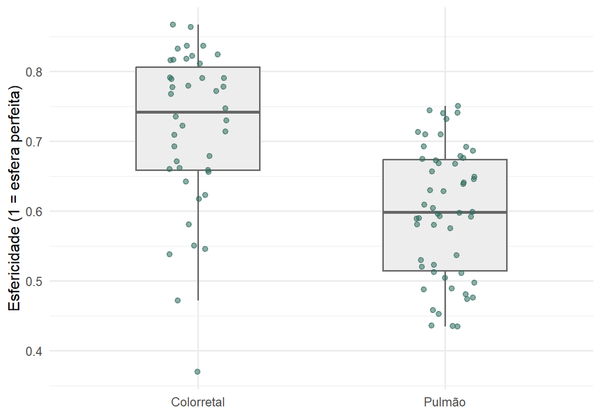

Figura 1. Esfericidade por diagnóstico. Valores próximos de 1 indicam lesões arredondadas; valores menores, bordas mais irregulares.

```r
data.frame(esf = esf_base, dx = factor(ifelse(y == 1, "Pulmão", "Colorretal"),
                                       levels = c("Colorretal", "Pulmão"))) %>%
  ggplot(aes(dx, esf)) +
  geom_boxplot(width = .5, outlier.shape = NA, fill = "grey93", colour = "grey40") +
  geom_jitter(width = .12, height = 0, alpha = .55, size = 1.8, colour = "#2F6B5E") +
  labs(x = NULL, y = "Esfericidade (1 = esfera perfeita)") +
  theme_minimal(base_size = 12)
```

> A esfericidade mediana é de 0,598 nas lesões pulmonares e de 0,741 nas colorretais: as lesões pulmonares são menos esféricas, isto é, têm bordas mais irregulares, como descrito na literatura. Embora a esfericidade não dependa do tamanho por construção, nesta amostra ela tem correlação de Spearman de -0,57 com o volume: lesões maiores tendem a ser menos esféricas.

## 5.4 Como é a esfericidade: radiômica inversa

Valores de esfericidade são pouco intuitivos: o que significa, visualmente, uma lesão com esfericidade de 0,74 ou de 0,60? Para responder, faz-se o caminho inverso da radiômica: em vez de extrair a esfericidade de imagens, **geram-se lesões sintéticas com a esfericidade observada nos dados** e observa-se a forma resultante.

A abordagem segue a ideia de Limkin et al. (2019), que construíram modelos de tumor com graus controlados de espiculação, imprimiram-nos em 3D, obtiveram tomografias e mostraram que a esfericidade diminui à medida que a espiculação aumenta, sendo um dos descritores de forma menos afetados pelo volume. Aqui, os modelos são apenas computacionais:

1. parte-se de uma esfera e acrescentam-se irregularidades à superfície: lobulações largas e médias, sem espículas, nas lesões colorretais (metástases tendem a ter contorno liso ou lobulado; Lee, Jeong e Kim, 2021), e lobulações com espículas nas pulmonares;
2. a intensidade das irregularidades é ajustada até que a esfericidade coincida com a mediana e com os quartis observados em cada diagnóstico;
3. cada forma tem o volume mediano do seu grupo e é representada em voxels de 1 mm, como as imagens do banco;
4. a esfericidade é calculada pela malha de superfície obtida pelo algoritmo *marching cubes* (Lorensen e Cline, 1987), como no PyRadiomics.

As formas foram geradas pelo script `radiomica_inversa_voxel.py`, em Python, com as bibliotecas NumPy, scikit-image (van der Walt et al., 2014) e Matplotlib. A figura é incluída a seguir.

[figure not shown]

Figura 2. Radiômica inversa: lesões sintéticas com a esfericidade observada nos dados. Linha superior: forma tridimensional; linha inferior: corte axial de maior área, em voxels de 1 mm. Formas ilustrativas, geradas por computador.

> **O que a figura mostra.**
> - **Uma esfera perfeita, representada em voxels de 1 mm, já perde esfericidade.** Com 9 mm de diâmetro, ela tem esfericidade de 0,919, e não de 1, porque a superfície em degraus acrescenta área. O efeito é maior em lesões pequenas, como as colorretais desta amostra, o que está de acordo com a sensibilidade dos descritores de forma à resolução da imagem relatada por Limkin et al. (2019).
> - **A diferença entre os diagnósticos fica visível.** A lesão colorretal típica (esfericidade de 0,741) é compacta, com contorno ondulado; a pulmonar típica (0,598) é maior e tem projeções que saem da borda, e o seu corte axial lembra o aspecto espiculado descrito pelos radiologistas.

> As lesões são ilustrativas: muitas formas diferentes compartilham a mesma esfericidade, e as apresentadas são apenas exemplos plausíveis de cada grupo.

## 5.5 Regressão logística

O modelo base é uma regressão logística com a esfericidade como único preditor. Como a esfericidade varia entre 0 e 1, o efeito é expresso para uma **redução de 0,1** na esfericidade, o que corresponde a uma borda visivelmente mais irregular.

```r
fit_base <- glm(y ~ esf_base, family = binomial)
cf_base  <- summary(fit_base)$coefficients
ic_base  <- confint.default(fit_base)["esf_base", ]
rc_01    <- exp(-0.1 * cf_base["esf_base", "Estimate"])
ic_01    <- sort(exp(-0.1 * ic_base))
auc_ap   <- as.numeric(auc(roc(y, fitted(fit_base), direction = "<", levels = c(0, 1), quiet = TRUE)))

tab_logit <- data.frame(
  Termo = c("Intercepto", "Esfericidade"),
  Coeficiente = round(cf_base[, "Estimate"], 3),
  `Razão de chances (0,1 a menos de esfericidade)` = c("", sprintf("%.2f", rc_01)),
  `IC 95 %` = c("", sprintf("[%.2f; %.2f]", ic_01[1], ic_01[2])),
  `p-valor` = format.pval(cf_base[, "Pr(>|z|)"], digits = 2, eps = .001),
  check.names = FALSE, row.names = NULL)

kable(tab_logit, format = "html", row.names = FALSE, align = c("l", rep("c", 4)),
      caption = sprintf("Tabela 5. Regressão logística do modelo base (amostra completa, n = %d; desfecho: pulmão = 1; AUC aparente = %.3f)", n, auc_ap)) %>%
  kable_styling(bootstrap_options = c("striped", "condensed"), full_width = FALSE)
```

Tabela 5. Regressão logística do modelo base (amostra completa, n = 96; desfecho: pulmão = 1; AUC aparente = 0.804)

| Termo | Coeficiente | Razão de chances (0,1 a menos de esfericidade) | IC 95 % | p-valor |
| --- | --- | --- | --- | --- |
| Intercepto | 7.718 |  |  | <0.001 |
| Esfericidade | -11.300 | 3.10 | [1.87; 5.11] | <0.001 |

Para estimar o desempenho sem otimismo, o modelo é ajustado na mesma validação cruzada repetida usada pelos modelos radiômicos (10 repetições de 5 folds, estratificados por diagnóstico e protocolo), de modo que todas as comparações da Seção 13 são pareadas.

```r
estrato <- factor(paste0(ifelse(y == 1, "pulmao", "colorretal"), "_",
                         ifelse(ct == 1, "com", "sem")))

# Regressão logística em validação cruzada repetida: AUC out-of-fold por semente
cv_logit <- function(Z, seeds = N_SEEDS) {
  Z <- as.data.frame(Z)
  sapply(seq_len(seeds), function(s) {
    set.seed(1000 + s)
    folds <- caret::createFolds(estrato, k = N_FOLDS, list = TRUE)
    oof <- numeric(n)
    for (te in folds) {
      tr <- setdiff(seq_len(n), te)
      m  <- suppressWarnings(glm(y[tr] ~ ., data = Z[tr, , drop = FALSE], family = binomial))
      oof[te] <- predict(m, newdata = Z[te, , drop = FALSE], type = "response")
    }
    as.numeric(auc(roc(y, oof, direction = "<", levels = c(0, 1), quiet = TRUE)))
  })
}
ic_t <- function(x, nivel = .95) {
  e <- qt(1 - (1 - nivel) / 2, length(x) - 1) * sd(x) / sqrt(length(x)); mean(x) + c(-e, e)
}

auc_base <- cv_logit(data.frame(esfericidade = esf_base))

data.frame(
  `Repetições x folds` = sprintf("%d x %d", N_SEEDS, N_FOLDS),
  `AUC média` = round(mean(auc_base), 3),
  `Desvio padrão entre repetições` = round(sd(auc_base), 3),
  `Menor e maior AUC` = sprintf("%.3f a %.3f", min(auc_base), max(auc_base)),
  check.names = FALSE) %>%
  kable(format = "html", row.names = FALSE, align = "c",
        caption = "Tabela 6. Desempenho do modelo base na validação cruzada (AUC out-of-fold por repetição)") %>%
  kable_styling(bootstrap_options = c("striped", "condensed"), full_width = FALSE)
```

Tabela 6. Desempenho do modelo base na validação cruzada (AUC out-of-fold por repetição)

| Repetições x folds | AUC média | Desvio padrão entre repetições | Menor e maior AUC |
| --- | --- | --- | --- |
| 10 x 5 | 0.797 | 0.003 | 0.791 a 0.802 |

## 5.6 O protocolo de contraste afeta o modelo base?

Como a esfericidade não passaria no filtro do contraste, verifica-se o quanto o protocolo interfere no modelo base: o efeito do contraste sobre a variável em cada diagnóstico (delta de Cliff, como na Seção 6), a capacidade de discriminação dentro de cada protocolo e a regressão logística ajustada pelo protocolo.

```r
cliff_esf <- function(a, b) mean(sign(outer(a, b, "-")))
d_esf_pul <- cliff_esf(esf_base[y == 1 & ct == 1], esf_base[y == 1 & ct == 0])
d_esf_col <- cliff_esf(esf_base[y == 0 & ct == 1], esf_base[y == 0 & ct == 0])
auc_prot  <- function(i) as.numeric(auc(roc(y[i], esf_base[i], direction = ">", levels = c(0, 1), quiet = TRUE)))
m_aj  <- glm(y ~ esf_base + ct, family = binomial)
m_int <- glm(y ~ esf_base * ct, family = binomial)
rc_aj <- exp(-0.1 * coef(m_aj)["esf_base"])
ic_aj <- sort(exp(-0.1 * confint.default(m_aj)["esf_base", ]))
p_int <- summary(m_int)$coefficients["esf_base:ct", "Pr(>|z|)"]

tab_prot <- data.frame(
  Grupo = c("Pulmão", "Colorretal"),
  `Mediana com contraste` = sprintf("%.3f", c(median(esf_base[y == 1 & ct == 1]), median(esf_base[y == 0 & ct == 1]))),
  `Mediana sem contraste` = sprintf("%.3f", c(median(esf_base[y == 1 & ct == 0]), median(esf_base[y == 0 & ct == 0]))),
  `Delta de Cliff (com vs. sem)` = round(c(d_esf_pul, d_esf_col), 3),
  Magnitude = ifelse(abs(c(d_esf_pul, d_esf_col)) < 0.147, "Desprezível",
                     ifelse(abs(c(d_esf_pul, d_esf_col)) < 0.33, "Pequeno", "Médio ou grande")),
  check.names = FALSE)

kable(tab_prot, format = "html", row.names = FALSE, align = c("l", "c", "c", "c", "c"),
      caption = "Tabela 7. Esfericidade por diagnóstico e protocolo de contraste") %>%
  kable_styling(bootstrap_options = c("striped", "condensed"), full_width = FALSE)
```

Tabela 7. Esfericidade por diagnóstico e protocolo de contraste

| Grupo | Mediana com contraste | Mediana sem contraste | Delta de Cliff (com vs. sem) | Magnitude |
| --- | --- | --- | --- | --- |
| Pulmão | 0.598 | 0.604 | -0.051 | Desprezível |
| Colorretal | 0.714 | 0.772 | -0.240 | Pequeno |

```r
data.frame(
  Medida = c("AUC entre os exames com contraste", "AUC entre os exames sem contraste",
             "Razão de chances (0,1 a menos de esfericidade), sem ajuste",
             "Razão de chances (0,1 a menos de esfericidade), ajustada pelo protocolo",
             "p-valor da interação esfericidade x protocolo"),
  Valor = c(sprintf("%.3f (n = %d)", auc_prot(ct == 1), sum(ct == 1)),
            sprintf("%.3f (n = %d)", auc_prot(ct == 0), sum(ct == 0)),
            sprintf("%.2f [%.2f; %.2f]", rc_01, ic_01[1], ic_01[2]),
            sprintf("%.2f [%.2f; %.2f]", rc_aj, ic_aj[1], ic_aj[2]),
            format.pval(p_int, digits = 2, eps = .001))) %>%
  kable(format = "html", row.names = FALSE, align = c("l", "c"),
        caption = "Tabela 8. Sensibilidade do modelo base ao protocolo de contraste (amostra completa)") %>%
  kable_styling(bootstrap_options = c("striped", "condensed"), full_width = FALSE)
```

Tabela 8. Sensibilidade do modelo base ao protocolo de contraste (amostra completa)

| Medida | Valor |
| --- | --- |
| AUC entre os exames com contraste | 0.760 (n = 56) |
| AUC entre os exames sem contraste | 0.896 (n = 40) |
| Razão de chances (0,1 a menos de esfericidade), sem ajuste | 3.10 [1.87; 5.11] |
| Razão de chances (0,1 a menos de esfericidade), ajustada pelo protocolo | 3.32 [1.96; 5.63] |
| p-valor da interação esfericidade x protocolo | 0.094 |

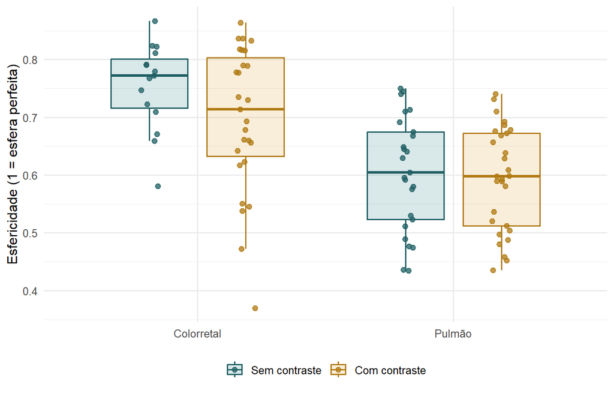

Figura 3. Esfericidade por diagnóstico, separada pelo protocolo de contraste. Cada ponto é um paciente.

```r
data.frame(esf = esf_base,
           dx = factor(ifelse(y == 1, "Pulmão", "Colorretal"), levels = c("Colorretal", "Pulmão")),
           protocolo = factor(ifelse(ct == 1, "Com contraste", "Sem contraste"),
                              levels = c("Sem contraste", "Com contraste"))) %>%
  ggplot(aes(dx, esf, fill = protocolo, colour = protocolo)) +
  geom_boxplot(width = .6, outlier.shape = NA, alpha = .18,
               position = position_dodge(width = .75)) +
  geom_point(size = 2, alpha = .75,
             position = position_jitterdodge(jitter.width = .15, dodge.width = .75, seed = 1)) +
  scale_fill_manual(values = c("Sem contraste" = "#2A7F84", "Com contraste" = "#E0A030"), name = NULL) +
  scale_colour_manual(values = c("Sem contraste" = "#1F5F63", "Com contraste" = "#B07A12"), name = NULL) +
  labs(x = NULL, y = "Esfericidade (1 = esfera perfeita)") +
  theme_minimal(base_size = 12) + theme(legend.position = "bottom")
```

> Nos pulmonares, o contraste praticamente não altera a esfericidade (delta de -0,051); nos colorretais, as lesões examinadas com contraste são menos esféricas (delta de -0,240, efeito pequeno), o que as aproxima das pulmonares. Por isso, a discriminação é melhor entre os exames sem contraste (AUC de 0,896) do que entre os com contraste (0,760). Ainda assim, a esfericidade separa os diagnósticos nos dois protocolos, e o efeito estimado praticamente não muda quando o modelo é ajustado pelo protocolo (razão de chances de 3,10 sem ajuste e 3,32 com ajuste). A interação entre esfericidade e protocolo não é significativa a 5 % (p = 0,094), mas o tamanho da amostra limita esse teste. Com estes dados, não é possível separar um efeito do contraste sobre a segmentação de diferenças entre os pacientes que realizaram cada exame.

## 5.7 Regra de classificação

Para uso clínico, a probabilidade estimada é convertida numa regra simples: lesões com esfericidade **abaixo** de um ponto de corte são classificadas como pulmonares. O corte é escolhido pelo índice de Youden, que equilibra sensibilidade e especificidade.

```r
roc_esf <- roc(y, esf_base, direction = ">", levels = c(0, 1), quiet = TRUE)
corte_youden <- coords(roc_esf, "best", best.method = "youden",
                       ret = c("threshold", "sensitivity", "specificity"), transpose = FALSE)[1, ]

metricas <- function(real, prev) {
  vp <- sum(real == 1 & prev == 1); fn <- sum(real == 1 & prev == 0)
  vn <- sum(real == 0 & prev == 0); fp <- sum(real == 0 & prev == 1)
  c(Sensibilidade = vp / (vp + fn), Especificidade = vn / (vn + fp),
    `Valor preditivo positivo` = vp / (vp + fp), `Valor preditivo negativo` = vn / (vn + fn),
    Acurácia = (vp + vn) / length(real))
}

prev_corte <- as.integer(esf_base < corte_youden$threshold)
met_ap <- metricas(y, prev_corte)

data.frame(
  `Ponto de corte (esfericidade)` = sprintf("%.3f", corte_youden$threshold),
  Regra = sprintf("Abaixo de %.3f: pulmão", corte_youden$threshold),
  Sensibilidade = pct(met_ap["Sensibilidade"]),
  Especificidade = pct(met_ap["Especificidade"]),
  check.names = FALSE) %>%
  kable(format = "html", row.names = FALSE, align = "c",
        caption = "Tabela 9. Ponto de corte da esfericidade pelo índice de Youden (amostra completa)") %>%
  kable_styling(bootstrap_options = c("striped", "condensed"), full_width = FALSE)
```

Tabela 9. Ponto de corte da esfericidade pelo índice de Youden (amostra completa)

| Ponto de corte (esfericidade) | Regra | Sensibilidade | Especificidade |
| --- | --- | --- | --- |
| 0.714 | Abaixo de 0.714: pulmão | 91 % | 60 % |

### Tabela de classificação

```r
mc <- table(Real = factor(y, levels = c(0, 1)), Previsto = factor(prev_corte, levels = c(0, 1)))

tab_mc <- data.frame(
  `Diagnóstico real` = c("Colorretal", "Pulmão", "Total"),
  `Classificado como colorretal` = c(mc["0", "0"], mc["1", "0"], sum(mc[, "0"])),
  `Classificado como pulmão` = c(mc["0", "1"], mc["1", "1"], sum(mc[, "1"])),
  Total = c(sum(mc["0", ]), sum(mc["1", ]), sum(mc)),
  check.names = FALSE)

kable(tab_mc, format = "html", row.names = FALSE, align = c("l", "c", "c", "c"),
      caption = sprintf("Tabela 10. Classificação pela regra da esfericidade (corte de %.3f; amostra completa)",
                        corte_youden$threshold)) %>%
  kable_styling(bootstrap_options = c("condensed", "bordered"), full_width = FALSE) %>%
  row_spec(3, bold = TRUE) %>%
  column_spec(1, bold = TRUE)
```

Tabela 10. Classificação pela regra da esfericidade (corte de 0.714; amostra completa)

| Diagnóstico real | Classificado como colorretal | Classificado como pulmão | Total |
| --- | --- | --- | --- |
| Colorretal | 25 | 17 | 42 |
| Pulmão | 5 | 49 | 54 |
| Total | 30 | 66 | 96 |

A tabela acima usa o ponto de corte escolhido nos mesmos pacientes em que é avaliado, o que tende a superestimar o desempenho. Para estimar o desempenho esperado em pacientes novos, o corte é escolhido pelo índice de Youden **apenas com os pacientes de treino** de cada fold e aplicado aos pacientes de teste, nas mesmas 10 repetições da validação cruzada.

```r
corte_cv <- lapply(seq_len(N_SEEDS), function(s) {
  set.seed(1000 + s)
  folds <- caret::createFolds(estrato, k = N_FOLDS, list = TRUE)
  prev <- integer(n); cortes <- numeric(length(folds))
  for (f in seq_along(folds)) {
    te <- folds[[f]]; tr <- setdiff(seq_len(n), te)
    r_tr <- roc(y[tr], esf_base[tr], direction = ">", levels = c(0, 1), quiet = TRUE)
    cortes[f] <- coords(r_tr, "best", best.method = "youden", ret = "threshold",
                        transpose = FALSE)[1, 1]
    prev[te] <- as.integer(esf_base[te] < cortes[f])
  }
  list(prev = prev, cortes = cortes)
})

met_cv    <- t(sapply(corte_cv, function(r) metricas(y, r$prev)))
cortes_cv <- unlist(lapply(corte_cv, `[[`, "cortes"))
mc_cv     <- Reduce(`+`, lapply(corte_cv, function(r)
  table(factor(y, levels = c(0, 1)), factor(r$prev, levels = c(0, 1))))) / N_SEEDS

tab_met <- data.frame(
  Medida = colnames(met_cv),
  `Amostra completa` = pct(met_ap),
  `Validação cruzada: média` = pct(colMeans(met_cv)),
  `Validação cruzada: menor e maior` = sprintf("%s a %s", pct(apply(met_cv, 2, min)), pct(apply(met_cv, 2, max))),
  check.names = FALSE, row.names = NULL)

kable(tab_met, format = "html", row.names = FALSE, align = c("l", "c", "c", "c"),
      caption = sprintf("Tabela 11. Desempenho da regra de classificação: amostra completa e validação cruzada (%d repetições; corte escolhido no treino de cada fold)", N_SEEDS)) %>%
  kable_styling(bootstrap_options = c("striped", "condensed"), full_width = FALSE)
```

Tabela 11. Desempenho da regra de classificação: amostra completa e validação cruzada (10 repetições; corte escolhido no treino de cada fold)

| Medida | Amostra completa | Validação cruzada: média | Validação cruzada: menor e maior |
| --- | --- | --- | --- |
| Sensibilidade | 91 % | 85 % | 78 % a 91 % |
| Especificidade | 60 % | 54 % | 50 % a 60 % |
| Valor preditivo positivo | 74 % | 71 % | 69 % a 73 % |
| Valor preditivo negativo | 83 % | 74 % | 67 % a 81 % |
| Acurácia | 77 % | 72 % | 69 % a 74 % |

> Na validação cruzada, os pontos de corte escolhidos nos treinos variaram de 0,653 a 0,759 (mediana de 0,714). Em média por repetição, a regra classificou corretamente 46,0 dos 54 pacientes pulmonares e 22,8 dos 42 colorretais.

**Como ler o modelo base**

- **Efeito da irregularidade.** A cada redução de 0,1 na esfericidade, a chance de a lesão ser pulmonar é multiplicada por **3,10** (IC 95 %: 1,87 a 5,11). Bordas mais irregulares indicam maior probabilidade de adenocarcinoma pulmonar, em acordo com a indicação clínica e com a literatura.
- **Capacidade de discriminação.** Na validação cruzada, o modelo alcança AUC de **0,797**: em cerca de 80 % dos pares formados por um paciente de cada diagnóstico, a lesão pulmonar recebe maior probabilidade de ser pulmonar. O desempenho praticamente não varia entre as repetições (desvio padrão de 0,003).
- **Uso clínico.** Lesões com esfericidade abaixo de **0,714** são classificadas como pulmonares, com sensibilidade de 91 % e especificidade de 60 % na amostra completa. O modelo identifica bem as lesões pulmonares, mas classifica como pulmonar parte das colorretais com borda irregular, em geral as maiores.
- **Desempenho esperado em pacientes novos.** Escolhendo o corte apenas com os pacientes de treino, a sensibilidade média é de 85 % e a especificidade, de 54 %. Essa é a estimativa mais honesta do desempenho da regra; uma validação em outra amostra ainda seria necessária.

# 6. Efeito do contraste sobre cada descritor

## 6.1 Método

O efeito do contraste é medido, para cada descritor, pelo **delta de Cliff** entre exames com e sem contraste (Cliff, 1993):

$$\delta = P(X_{\text{com}} >
X_{\text{sem}}) - P(X_{\text{com}} < X_{\text{sem}}).$$

O delta compara todos os pares formados por um paciente com contraste e um sem contraste. Varia de $-1$ a $1$, é zero quando os dois grupos se sobrepõem completamente, não depende da escala do descritor e é robusto a assimetria e a valores extremos, frequentes em descritores radiômicos.

O cálculo é feito **separadamente em cada diagnóstico**, de modo que a comparação seja sempre entre pacientes com o mesmo tipo de tumor. Um descritor é considerado **sem efeito do contraste** quando o efeito é desprezível nos dois diagnósticos:

$$|\delta_{\text{pulmão}}| < 0{,}147
\quad \text{e} \quad |\delta_{\text{colorretal}}| <
0{,}147.$$

O limiar de 0,147 é o limite superior do efeito desprezível na convenção de Romano et al. (2006), que classifica $|\delta|$ em desprezível (até 0,147), pequeno (até 0,33), médio (até 0,474) e grande.

Esse critério é mais exigente do que usar a média dos dois deltas: na média, efeitos de sinais opostos nos dois diagnósticos podem se cancelar. A lapidação usa apenas o protocolo e os descritores, nunca o desfecho, e por isso não introduz vazamento de informação sobre o diagnóstico nas etapas seguintes.

## 6.2 Cálculo

```r
cliff_delta <- function(a, b) mean(sign(outer(a, b, "-")))

efeito <- data.frame(
  descritor        = feat,
  familia          = familia,
  delta_pulmao     = sapply(seq_len(p), function(j)
                       cliff_delta(X[y == 1 & ct == 1, j], X[y == 1 & ct == 0, j])),
  delta_colorretal = sapply(seq_len(p), function(j)
                       cliff_delta(X[y == 0 & ct == 1, j], X[y == 0 & ct == 0, j])))

efeito$max_abs <- pmax(abs(efeito$delta_pulmao), abs(efeito$delta_colorretal))
efeito$desprezivel <- efeito$max_abs < LIM_DESPREZIVEL

classifica <- function(a) cut(a, c(-Inf, .147, .33, .474, Inf), right = FALSE,
                              labels = c("Desprezível", "Pequeno", "Médio", "Grande"))
efeito$mag_pulmao     <- classifica(abs(efeito$delta_pulmao))
efeito$mag_colorretal <- classifica(abs(efeito$delta_colorretal))

cat("Descritores com efeito desprezível nos dois diagnósticos:",
    sum(efeito$desprezivel), "de", p, "\n")
```

```
## Descritores com efeito desprezível nos dois diagnósticos: 18 de 105
```

```r
fam_niv <- names(sort(table(familia), decreasing = TRUE))
tab_fam <- efeito %>%
  mutate(familia = factor(familia, fam_niv)) %>%
  group_by(Família = familia) %>%
  summarise(Total = n(),
            `Desprezível no pulmão` = sum(mag_pulmao == "Desprezível"),
            `Desprezível no colorretal` = sum(mag_colorretal == "Desprezível"),
            `Desprezível nos dois` = sum(desprezivel), .groups = "drop")
tab_fam <- rbind(tab_fam, data.frame(Família = "Total", t(colSums(tab_fam[, -1])),
                                     check.names = FALSE))

kable(tab_fam, format = "html", align = c("l", rep("c", 4)),
      caption = "Tabela 12. Descritores com efeito desprezível do contraste, por família") %>%
  kable_styling(bootstrap_options = c("striped", "condensed"), full_width = FALSE) %>%
  row_spec(nrow(tab_fam), bold = TRUE)
```

Tabela 12. Descritores com efeito desprezível do contraste, por família

| Família | Total | Desprezível no pulmão | Desprezível no colorretal | Desprezível nos dois |
| --- | --- | --- | --- | --- |
| glcm | 22 | 5 | 14 | 2 |
| firstorder | 18 | 4 | 10 | 3 |
| glrlm | 16 | 3 | 11 | 3 |
| glszm | 16 | 5 | 7 | 4 |
| gldm | 14 | 5 | 6 | 3 |
| shape | 14 | 3 | 3 | 2 |
| ngtdm | 5 | 1 | 2 | 1 |
| Total | 105 | 26 | 53 | 18 |

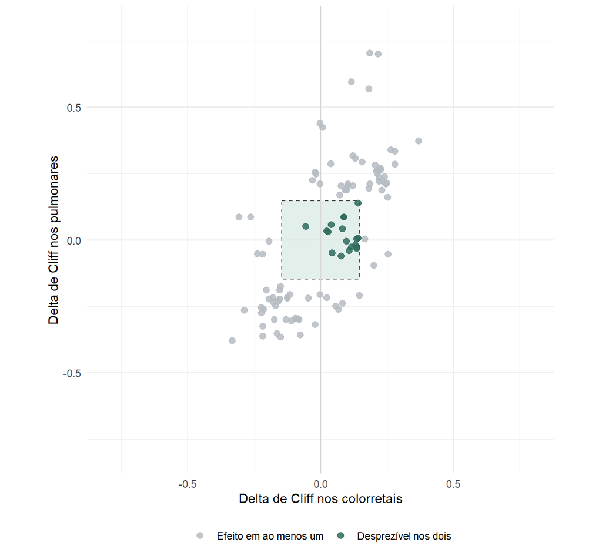

Figura 4. Delta de Cliff (com contraste contra sem contraste) nos colorretais e nos pulmonares. O quadrado tracejado delimita a região de efeito desprezível nos dois diagnósticos; os descritores dentro dele formam o conjunto lapidado.

```r
lim <- LIM_DESPREZIVEL
ggplot(efeito, aes(delta_colorretal, delta_pulmao)) +
  annotate("rect", xmin = -lim, xmax = lim, ymin = -lim, ymax = lim,
           fill = "#E3EFEB", colour = "grey30", linetype = 2) +
  geom_hline(yintercept = 0, colour = "grey85") +
  geom_vline(xintercept = 0, colour = "grey85") +
  geom_point(aes(colour = desprezivel), size = 2.3, alpha = .85) +
  scale_colour_manual(values = c(`TRUE` = "#2F6B5E", `FALSE` = "#B5BCC2"),
                      labels = c(`TRUE` = "Desprezível nos dois", `FALSE` = "Efeito em ao menos um"),
                      name = NULL) +
  coord_equal(xlim = c(-.8, .8), ylim = c(-.8, .8)) +
  labs(x = "Delta de Cliff nos colorretais", y = "Delta de Cliff nos pulmonares") +
  theme_minimal(base_size = 11) + theme(legend.position = "bottom")
```

**Tabela 13. Delta de Cliff dos 105 descritores** (clique para abrir)**

```r
efeito %>%
  arrange(max_abs) %>%
  transmute(Descritor = nome(descritor), Família = familia,
            `Delta pulmão` = round(delta_pulmao, 3), `Magnitude pulmão` = mag_pulmao,
            `Delta colorretal` = round(delta_colorretal, 3), `Magnitude colorretal` = mag_colorretal,
            `Sem efeito do contraste` = ifelse(desprezivel, "sim", "não")) %>%
  kable(format = "html", row.names = FALSE, align = c("l", "l", rep("c", 5))) %>%
  kable_styling(bootstrap_options = c("hover", "condensed"), font_size = 12) %>%
  row_spec(which(sort(efeito$max_abs) < LIM_DESPREZIVEL), background = "#E3EFEB") %>%
  scroll_box(height = "520px")
```

| Descritor | Família | Delta pulmão | Magnitude pulmão | Delta colorretal | Magnitude colorretal | Sem efeito do contraste |
| --- | --- | --- | --- | --- | --- | --- |
| glszm_SmallAreaEmphasis | glszm | 0.032 | Desprezível | 0.027 | Desprezível | sim |
| glszm_SizeZoneNonUniformityNormalized | glszm | 0.034 | Desprezível | 0.022 | Desprezível | sim |
| shape_Elongation | shape | -0.048 | Desprezível | 0.042 | Desprezível | sim |
| shape_Flatness | shape | 0.051 | Desprezível | -0.057 | Desprezível | sim |
| firstorder_Range | firstorder | 0.058 | Desprezível | 0.040 | Desprezível | sim |
| ngtdm_Complexity | ngtdm | -0.059 | Desprezível | 0.077 | Desprezível | sim |
| gldm_DependenceEntropy | gldm | 0.043 | Desprezível | 0.081 | Desprezível | sim |
| firstorder_Energy | firstorder | 0.087 | Desprezível | 0.086 | Desprezível | sim |
| firstorder_TotalEnergy | firstorder | 0.087 | Desprezível | 0.086 | Desprezível | sim |
| glszm_ZoneEntropy | glszm | -0.004 | Desprezível | 0.096 | Desprezível | sim |
| glcm_Autocorrelation | glcm | -0.040 | Desprezível | 0.106 | Desprezível | sim |
| glcm_JointAverage | glcm | -0.026 | Desprezível | 0.116 | Desprezível | sim |
| glrlm_HighGrayLevelRunEmphasis | glrlm | -0.018 | Desprezível | 0.131 | Desprezível | sim |
| glrlm_ShortRunHighGrayLevelEmphasis | glrlm | -0.032 | Desprezível | 0.136 | Desprezível | sim |
| glszm_HighGrayLevelZoneEmphasis | glszm | 0.004 | Desprezível | 0.136 | Desprezível | sim |
| gldm_HighGrayLevelEmphasis | gldm | -0.026 | Desprezível | 0.136 | Desprezível | sim |
| glrlm_LongRunHighGrayLevelEmphasis | glrlm | 0.007 | Desprezível | 0.141 | Desprezível | sim |
| gldm_LargeDependenceHighGrayLevelEmphasis | gldm | 0.139 | Desprezível | 0.141 | Desprezível | sim |
| glszm_SmallAreaHighGrayLevelEmphasis | glszm | 0.004 | Desprezível | 0.165 | Pequeno | não |
| gldm_DependenceVariance | gldm | 0.170 | Pequeno | 0.072 | Desprezível | não |
| glszm_SmallAreaLowGrayLevelEmphasis | glszm | -0.175 | Pequeno | -0.151 | Pequeno | não |
| glcm_Idm | glcm | 0.189 | Pequeno | 0.091 | Desprezível | não |
| glrlm_RunVariance | glrlm | 0.189 | Pequeno | 0.096 | Desprezível | não |
| glszm_LowGrayLevelZoneEmphasis | glszm | -0.189 | Pequeno | -0.156 | Pequeno | não |
| glszm_SizeZoneNonUniformity | glszm | 0.194 | Pequeno | 0.180 | Pequeno | não |
| glcm_MaximumProbability | glcm | -0.004 | Desprezível | -0.195 | Pequeno | não |
| gldm_SmallDependenceHighGrayLevelEmphasis | gldm | -0.095 | Desprezível | 0.200 | Pequeno | não |
| glrlm_LongRunLowGrayLevelEmphasis | glrlm | -0.189 | Pequeno | -0.205 | Pequeno | não |
| glcm_Id | glcm | 0.206 | Pequeno | 0.077 | Desprezível | não |
| glcm_InverseVariance | glcm | 0.206 | Pequeno | 0.121 | Desprezível | não |

[output cut: 75 more lines]

# 7. O conjunto lapidado

```r
X_full <- X; feat_full <- feat; familia_full <- familia; p_full <- p

keep    <- which(efeito$desprezivel)
X       <- X_full[, keep, drop = FALSE]
feat    <- feat_full[keep]
familia <- familia_full[keep]
p       <- ncol(X)

cat("Conjunto lapidado:", p, "descritores | razão p/n =", round(p / n, 2), "\n")
```

```
## Conjunto lapidado: 18 descritores | razão p/n = 0.19
```

```r
efeito[keep, ] %>%
  mutate(ordem = match(familia, fam_niv)) %>%
  arrange(ordem, max_abs) %>%
  transmute(Descritor = nome(descritor), Família = familia,
            `Delta pulmão` = round(delta_pulmao, 3),
            `Delta colorretal` = round(delta_colorretal, 3)) %>%
  kable(format = "html", row.names = FALSE, align = c("l", "l", "c", "c"),
        caption = sprintf("Tabela 14. Os %d descritores sem efeito do contraste nos dois diagnósticos", p)) %>%
  kable_styling(bootstrap_options = c("striped", "condensed"), full_width = FALSE)
```

Tabela 14. Os 18 descritores sem efeito do contraste nos dois diagnósticos

| Descritor | Família | Delta pulmão | Delta colorretal |
| --- | --- | --- | --- |
| glcm_Autocorrelation | glcm | -0.040 | 0.106 |
| glcm_JointAverage | glcm | -0.026 | 0.116 |
| firstorder_Range | firstorder | 0.058 | 0.040 |
| firstorder_Energy | firstorder | 0.087 | 0.086 |
| firstorder_TotalEnergy | firstorder | 0.087 | 0.086 |
| glrlm_HighGrayLevelRunEmphasis | glrlm | -0.018 | 0.131 |
| glrlm_ShortRunHighGrayLevelEmphasis | glrlm | -0.032 | 0.136 |
| glrlm_LongRunHighGrayLevelEmphasis | glrlm | 0.007 | 0.141 |
| glszm_SmallAreaEmphasis | glszm | 0.032 | 0.027 |
| glszm_SizeZoneNonUniformityNormalized | glszm | 0.034 | 0.022 |
| glszm_ZoneEntropy | glszm | -0.004 | 0.096 |
| glszm_HighGrayLevelZoneEmphasis | glszm | 0.004 | 0.136 |
| gldm_DependenceEntropy | gldm | 0.043 | 0.081 |
| gldm_HighGrayLevelEmphasis | gldm | -0.026 | 0.136 |
| gldm_LargeDependenceHighGrayLevelEmphasis | gldm | 0.139 | 0.141 |
| shape_Elongation | shape | -0.048 | 0.042 |
| shape_Flatness | shape | 0.051 | -0.057 |
| ngtdm_Complexity | ngtdm | -0.059 | 0.077 |

> O conjunto lapidado reúne 18 dos 105 descritores (17 %), com razão $p/n \approx$ 0,19. Apenas 2 dos 14 descritores de forma permaneceram. Como a forma depende apenas da segmentação, a exclusão dos demais reflete diferenças entre os pacientes que fizeram cada tipo de exame, e não um efeito físico do contraste: o protocolo não foi atribuído ao acaso.

# 8. Seleção de variáveis no conjunto lapidado

## 8.1 Procedimento

A pergunta é quais descritores lapidados o modelo escolhe com mais frequência. O Random Forest não seleciona variáveis por conta própria: ele atribui uma importância a todos os descritores. O conjunto selecionado em cada ajuste é formado pelos $k$ descritores de maior importância, e a **frequência de seleção** de um descritor é a proporção de ajustes em que ele aparece nesse conjunto.

O desenho de validação é o seguinte:

- **Validação cruzada externa** com 5 folds, repetida em 10 sementes, totalizando 50 ajustes. Cada ajuste usa cerca de 4/5 dos pacientes, e a variação entre os ajustes mostra o quanto a seleção depende da amostra.
- **Validação cruzada interna** com 3 folds, dentro do treino de cada fold externo, usada apenas para escolher o `mtry` (número de descritores sorteados em cada divisão das árvores).
- **Estratificação conjunta por diagnóstico e protocolo**, para que todos os folds tenham composição semelhante nos quatro grupos.
- **Importância por permutação** (`MeanDecreaseAccuracy`): queda da acurácia quando o descritor é embaralhado nos pacientes não usados no treino de cada árvore. A importância por redução de impureza de Gini é enviesada em favor de variáveis com muitos pontos de corte possíveis (Strobl et al., 2007).
- **Padronização estimada apenas no treino** de cada fold. Não altera o Random Forest, mas mantém o pipeline pronto para modelos que dependem de escala.

```r
estrato <- factor(paste0(ifelse(y == 1, "pulmao", "colorretal"), "_",
                         ifelse(ct == 1, "com", "sem")))
print(table(estrato))
```

```
## estrato
## colorretal_com colorretal_sem     pulmao_com     pulmao_sem
##             27             15             29             25
```

```r
roda_rf <- function(Xu = X, yy = y, estratos = estrato, seeds = N_SEEDS) {
  pu <- ncol(Xu); nn <- nrow(Xu)
  imp      <- matrix(NA_real_, nrow = seeds * N_FOLDS, ncol = pu,
                     dimnames = list(NULL, colnames(Xu)))
  seed_fit <- integer(seeds * N_FOLDS)
  mtry_esc <- integer(seeds * N_FOLDS)
  auc_fold <- numeric(seeds * N_FOLDS)
  oof      <- matrix(NA_real_, nrow = seeds, ncol = nn)
  grade    <- unique(round(c(sqrt(pu), pu / 8, pu / 4, pu / 2)))
  grade    <- grade[grade >= 1]
  linha    <- 0

  for (s in seq_len(seeds)) {
    set.seed(1000 + s)
    folds <- caret::createFolds(estratos, k = N_FOLDS, list = TRUE)

    for (te in folds) {
      linha <- linha + 1; seed_fit[linha] <- s
      tr <- setdiff(seq_len(nn), te)

      mu <- colMeans(Xu[tr, , drop = FALSE])
      sg <- apply(Xu[tr, , drop = FALSE], 2, sd); sg[sg == 0] <- 1
      Xtr <- scale(Xu[tr, , drop = FALSE], mu, sg)
      Xte <- scale(Xu[te, , drop = FALSE], mu, sg)

      # escolha do mtry por validação cruzada interna (AUC)
      set.seed(2000 + linha)
      fi <- caret::createFolds(factor(yy[tr]), k = N_FOLDS_I, list = TRUE)
      desemp <- sapply(grade, function(mt) mean(sapply(fi, function(vi) {
        ti <- setdiff(seq_along(tr), vi)
        mm <- randomForest(Xtr[ti, , drop = FALSE], factor(yy[tr][ti]),
                           ntree = NTREE_TUN, mtry = mt)
        pp <- predict(mm, Xtr[vi, , drop = FALSE], type = "prob")[, "1"]
        as.numeric(auc(roc(yy[tr][vi], pp, direction = "<", levels = c(0, 1), quiet = TRUE)))
      })))
      mtry_esc[linha] <- grade[which.max(desemp)]

      # ajuste final no treino do fold
      set.seed(3000 + linha)
      m <- randomForest(Xtr, factor(yy[tr]), ntree = NTREE,
                        mtry = mtry_esc[linha], importance = TRUE)
      imp[linha, ] <- importance(m, type = 1)[, 1]
      pr <- predict(m, Xte, type = "prob")[, "1"]
      oof[s, te] <- pr
      auc_fold[linha] <- as.numeric(auc(roc(yy[te], pr, direction = "<",
                                            levels = c(0, 1), quiet = TRUE)))
    }
  }
  auc_semente <- apply(oof, 1, function(pp)
    as.numeric(auc(roc(yy, pp, direction = "<", levels = c(0, 1), quiet = TRUE))))
  list(imp = imp, seed_fit = seed_fit, mtry = mtry_esc,
       auc_fold = auc_fold, auc_semente = auc_semente)
}
```

## 8.2 Execução

```r
t0 <- Sys.time()
rf <- roda_rf()
cat("Ajustes:", nrow(rf$imp), "| tempo:",
    round(difftime(Sys.time(), t0, units = "mins"), 1), "minutos\n")
```

```
## Ajustes: 50 | tempo: 0.2 minutos
```

```r
cat("mtry escolhido (frequência):\n"); print(table(rf$mtry))
```

```
## mtry escolhido (frequência):
```

```
##
##  2  4  9
## 13 20 17
```

## 8.3 Desempenho

```r
tab_auc <- data.frame(
  Estimativa = c("Média entre folds", "Por semente (predições out-of-fold)"),
  Réplicas   = c(length(rf$auc_fold), length(rf$auc_semente)),
  `AUC média` = round(c(mean(rf$auc_fold), mean(rf$auc_semente)), 3),
  `Desvio padrão` = round(c(sd(rf$auc_fold), sd(rf$auc_semente)), 3),
  check.names = FALSE)
kable(tab_auc, format = "html", align = c("l", "c", "c", "c"),
      caption = "Tabela 15. Desempenho do Random Forest no conjunto lapidado") %>%
  kable_styling(bootstrap_options = c("striped", "condensed"), full_width = FALSE)
```

Tabela 15. Desempenho do Random Forest no conjunto lapidado

| Estimativa | Réplicas | AUC média | Desvio padrão |
| --- | --- | --- | --- |
| Média entre folds | 50 | 0.737 | 0.095 |
| Por semente (predições out-of-fold) | 10 | 0.729 | 0.021 |

> A AUC por semente, calculada com as predições de todos os pacientes em cada repetição, foi de 0,729 (DP = 0,021). A AUC mede a capacidade de ordenar corretamente um paciente de cada diagnóstico; 0,5 corresponde ao acaso.

## 8.4 Frequência de seleção

```r
freq_k <- function(k) {
  sel <- t(apply(rf$imp, 1, function(v) {
    o <- order(v, decreasing = TRUE)[seq_len(k)]
    o <- o[v[o] > 0]                      # só entra se a importância for positiva
    seq_along(v) %in% o
  }))
  colMeans(sel)
}
frq <- sapply(K_GRID, freq_k); colnames(frq) <- paste0("k = ", K_GRID)

posto <- t(apply(-rf$imp, 1, rank, ties.method = "average"))  # 1 = mais importante

tab_freq <- data.frame(
  Descritor = nome(feat),
  Família   = familia,
  frq,
  `Posto médio` = colMeans(posto),
  `Importância média` = colMeans(rf$imp),
  check.names = FALSE, row.names = NULL)
ref <- paste0("k = ", TOP_K)
tab_freq <- tab_freq[order(-tab_freq[[ref]], tab_freq$`Posto médio`), ]

tab_freq %>%
  mutate(across(starts_with("k ="), ~ pct(.x)),
         `Posto médio` = round(`Posto médio`, 1),
         `Importância média` = round(`Importância média`, 2)) %>%
  kable(format = "html", row.names = FALSE, align = c("l", "l", rep("c", length(K_GRID) + 2)),
        caption = sprintf("Tabela 16. Frequência de seleção em %d ajustes, por tamanho do conjunto selecionado", nrow(rf$imp))) %>%
  kable_styling(bootstrap_options = c("striped", "hover", "condensed"), full_width = FALSE) %>%
  row_spec(which(tab_freq[[ref]] >= 0.95), bold = TRUE, background = "#E3EFEB")
```

Tabela 16. Frequência de seleção em 50 ajustes, por tamanho do conjunto selecionado

| Descritor | Família | k = 3 | k = 5 | k = 7 | Posto médio | Importância média |
| --- | --- | --- | --- | --- | --- | --- |
| firstorder_TotalEnergy | firstorder | 98 % | 100 % | 100 % | 1.5 | 9.71 |
| firstorder_Energy | firstorder | 98 % | 100 % | 100 % | 1.7 | 9.46 |
| gldm_DependenceEntropy | gldm | 46 % | 76 % | 80 % | 5.1 | 5.30 |
| glcm_JointAverage | glcm | 4 % | 50 % | 72 % | 6.4 | 4.09 |
| glcm_Autocorrelation | glcm | 10 % | 34 % | 62 % | 6.8 | 4.05 |
| glrlm_ShortRunHighGrayLevelEmphasis | glrlm | 8 % | 26 % | 50 % | 7.7 | 3.54 |
| gldm_LargeDependenceHighGrayLevelEmphasis | gldm | 8 % | 24 % | 48 % | 8.8 | 3.28 |
| glszm_SmallAreaEmphasis | glszm | 2 % | 16 % | 20 % | 11.4 | 2.04 |
| gldm_HighGrayLevelEmphasis | gldm | 6 % | 14 % | 34 % | 9.0 | 3.02 |
| glszm_SizeZoneNonUniformityNormalized | glszm | 6 % | 12 % | 20 % | 11.6 | 2.02 |
| glrlm_HighGrayLevelRunEmphasis | glrlm | 2 % | 10 % | 30 % | 9.8 | 2.73 |
| ngtdm_Complexity | ngtdm | 4 % | 10 % | 26 % | 10.3 | 2.63 |
| glszm_HighGrayLevelZoneEmphasis | glszm | 0 % | 8 % | 14 % | 12.3 | 1.83 |
| glrlm_LongRunHighGrayLevelEmphasis | glrlm | 0 % | 6 % | 12 % | 11.5 | 2.31 |
| shape_Flatness | shape | 4 % | 6 % | 8 % | 14.5 | 0.71 |
| shape_Elongation | shape | 4 % | 6 % | 12 % | 15.0 | 0.10 |
| firstorder_Range | firstorder | 0 % | 2 % | 10 % | 11.7 | 2.04 |
| glszm_ZoneEntropy | glszm | 0 % | 0 % | 2 % | 16.0 | -0.07 |

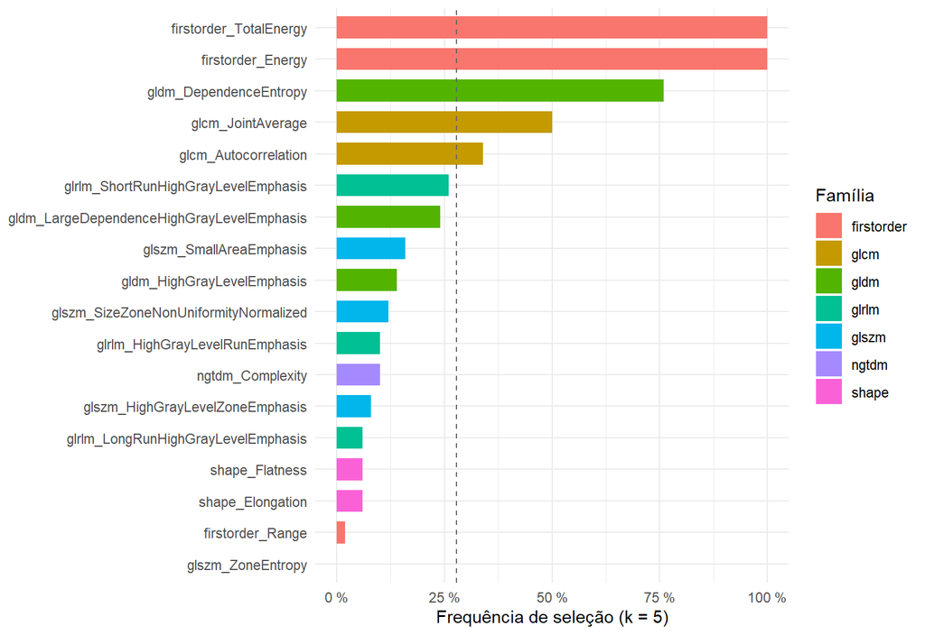

Figura 5. Frequência com que cada descritor lapidado aparece entre os 5 mais importantes de cada ajuste. A linha tracejada marca a frequência esperada se a seleção fosse ao acaso (k/p).

```r
data.frame(Descritor = factor(tab_freq$Descritor, rev(tab_freq$Descritor)),
           freq = tab_freq[[ref]], Família = tab_freq$Família) %>%
  ggplot(aes(freq, Descritor, fill = Família)) +
  geom_col(width = .7) +
  geom_vline(xintercept = TOP_K / p, linetype = 2, colour = "grey40") +
  scale_x_continuous(labels = function(x) paste0(x * 100, " %"), limits = c(0, 1)) +
  labs(x = sprintf("Frequência de seleção (k = %d)", TOP_K), y = NULL) +
  theme_minimal(base_size = 11)
```

> Com $k =$ 5, se os descritores fossem escolhidos ao acaso, cada um apareceria em cerca de 28 % dos ajustes. 2 descritor(es) foram selecionados em pelo menos 95 % dos ajustes: `firstorder_TotalEnergy` (100 %), `firstorder_Energy` (100 %). Os dois primeiros têm correlação de Spearman de 1,000 em valor absoluto, ou seja, são praticamente o mesmo descritor. A documentação do PyRadiomics indica que Energy e TotalEnergy são confundidos pelo volume da lesão, pois somam valores sobre todos os voxels (van Griethuysen et al., 2017). Na amostra, a correlação de Spearman entre Energy e VoxelVolume é de 0,892 em valor absoluto: embora o VoxelVolume tenha sido excluído pela lapidação, a informação de tamanho da lesão permanece no conjunto por meio desses descritores. Os demais se revezam entre os ajustes, o que motiva a etapa seguinte: verificar se esse revezamento ocorre entre descritores redundantes.

# 9. Agrupamento dos descritores lapidados

## 9.1 Método

Os descritores são agrupados por agrupamento hierárquico, com dissimilaridade derivada da correlação de Spearman em valor absoluto:

$$d_{ij} = 1 - |\rho_{ij}|.$$

A correlação de Spearman trabalha com postos, por isso é robusta a assimetria e a valores extremos e capta associações monótonas não lineares. O valor absoluto é usado porque, para efeito de redundância, importa a intensidade da associação e não o sinal: dois descritores com $\rho = -0{,}99$ carregam a mesma informação.

O agrupamento incide sobre as **colunas** (descritores), não sobre os pacientes. Usa-se a ligação média (*average linkage*), em que dois grupos são unidos quando a dissimilaridade média entre seus membros é pequena, e o dendrograma é cortado em $d =$ 0,20, o que corresponde a uma correlação absoluta média de pelo menos 0,80 entre os grupos unidos. O corte foi fixado por critério substantivo, e não pela otimização de um índice interno; Noortman et al. (2025), com o mesmo conjunto de descritores do PyRadiomics, usaram os limiares de 0,7 e 0,9, que são avaliados como sensibilidade na Seção 10.2.

```r
# Partição do espaço de descritores por distância de correlação
particao <- function(Xm, metodo = "spearman", ligacao = "average", h = CORTE) {
  r <- suppressWarnings(cor(Xm, method = metodo)); r[is.na(r)] <- 0
  D <- 1 - abs(r); diag(D) <- 0; D <- (D + t(D)) / 2
  cutree(hclust(as.dist(D), method = ligacao), h = h)
}
dist_ref <- function(Xm, metodo = "spearman") {
  r <- suppressWarnings(cor(Xm, method = metodo)); r[is.na(r)] <- 0
  D <- 1 - abs(r); diag(D) <- 0; D <- (D + t(D)) / 2
  as.dist(D)
}
# Índice de Rand Ajustado entre duas partições
ari <- function(a, b) {
  tb <- table(a, b)
  s_ij <- sum(choose(tb, 2)); s_a <- sum(choose(rowSums(tb), 2)); s_b <- sum(choose(colSums(tb), 2))
  esp <- s_a * s_b / choose(sum(tb), 2); mx <- (s_a + s_b) / 2
  if (isTRUE(all.equal(mx, esp))) return(1)
  (s_ij - esp) / (mx - esp)
}
# Jaccard entre dois conjuntos
jaccard <- function(a, b) { u <- length(union(a, b)); if (u == 0) 1 else length(intersect(a, b)) / u }
```

## 9.2 Redundância

```r
rho  <- cor(X, method = "spearman")
Aabs <- abs(rho); diag(Aabs) <- 0
vpar <- Aabs[upper.tri(Aabs)]
limiares <- c(0.70, 0.80, 0.90, 0.99)

tab_red <- data.frame(
  Limiar = sprintf("|rho| >= %.2f", limiares),
  Pares  = sapply(limiares, function(t) sum(vpar >= t)),
  `% dos pares` = sprintf("%.1f %%", 100 * sapply(limiares, function(t) mean(vpar >= t))),
  `Descritores com ao menos um par` = sapply(limiares, function(t) sum(rowSums(Aabs >= t) > 0)),
  check.names = FALSE)

kable(tab_red, format = "html", align = c("l", "c", "c", "c"),
      caption = sprintf("Tabela 17. Redundância entre os %d descritores lapidados (%d pares)",
                        p, choose(p, 2))) %>%
  kable_styling(bootstrap_options = c("striped", "condensed"), full_width = FALSE)
```

Tabela 17. Redundância entre os 18 descritores lapidados (153 pares)

| Limiar | Pares | % dos pares | Descritores com ao menos um par |
| --- | --- | --- | --- |
| \|rho\| >= 0.70 | 73 | 47.7 % | 18 |
| \|rho\| >= 0.80 | 47 | 30.7 % | 16 |
| \|rho\| >= 0.90 | 32 | 20.9 % | 15 |
| \|rho\| >= 0.99 | 15 | 9.8 % | 10 |

> Mesmo após a lapidação, 16 dos 18 descritores têm ao menos um par com $|\rho| \geq 0{,}80$, e 15 têm par com $|\rho| \geq 0{,}90$. A redundância continua sendo uma característica central do conjunto.

## 9.3 Visualização

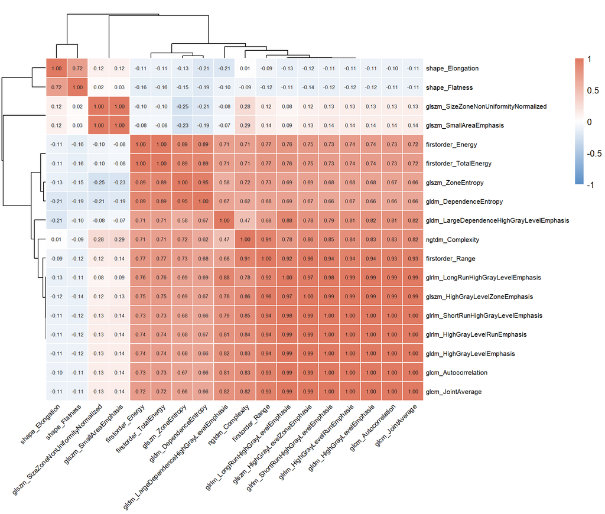

Figura 6. Correlação de Spearman entre os descritores lapidados, reordenada pelo agrupamento hierárquico. Blocos na diagonal indicam conjuntos de descritores redundantes.

```r
pheatmap(rho,
         color = colorRampPalette(c("#5B8FC7", "#FFFFFF", "#E07A62"))(100),
         breaks = seq(-1, 1, length.out = 101), number_color = "grey10",
         clustering_distance_rows = dist_ref(X), clustering_distance_cols = dist_ref(X),
         clustering_method = "average",
         display_numbers = TRUE, number_format = "%.2f", fontsize_number = 6.5,
         labels_row = nome(feat), labels_col = nome(feat),
         fontsize_row = 8, fontsize_col = 8, angle_col = 45,
         border_color = "white", main = "")
```

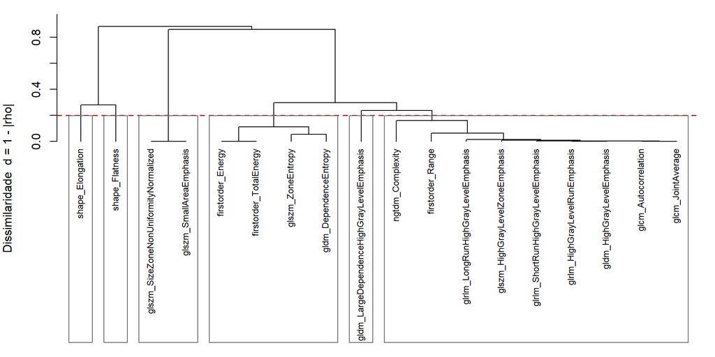

Figura 7. Dendrograma dos descritores lapidados. A linha tracejada marca o corte adotado; os retângulos delimitam os clusters.

```r
hc_ref <- hclust(dist_ref(X), method = "average")
par(mar = c(1, 4, 1, 1))
plot(hc_ref, labels = nome(feat), cex = 0.75, hang = -1,
     main = "", xlab = "", sub = "", ylab = "Dissimilaridade  d = 1 - |rho|")
abline(h = CORTE, lty = 2, col = "firebrick", lwd = 1.5)
rect.hclust(hc_ref, h = CORTE, border = "grey40")
```

## 9.4 Ponto de corte

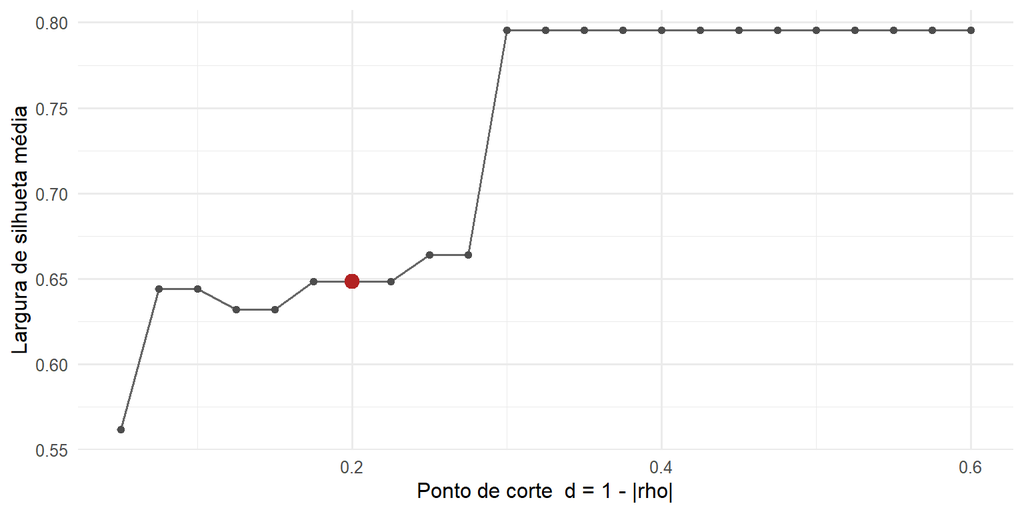

Figura 8. Largura de silhueta média em função do corte. O ponto vermelho é o corte adotado.

```r
d_obj  <- dist_ref(X)
cortes <- seq(0.05, 0.60, by = 0.025)
df_sil <- data.frame(
  corte = cortes,
  silhueta = sapply(cortes, function(h) {
    g <- cutree(hc_ref, h = h)
    if (length(unique(g)) < 2 || length(unique(g)) >= p) return(NA_real_)
    mean(silhouette(g, d_obj)[, "sil_width"])
  }),
  k = sapply(cortes, function(h) max(cutree(hc_ref, h = h))))

ggplot(df_sil, aes(corte, silhueta)) +
  geom_line(colour = "grey40") + geom_point(size = 1.6, colour = "grey30") +
  geom_point(data = subset(df_sil, abs(corte - CORTE) < 1e-8), size = 3.5, colour = "firebrick") +
  labs(x = "Ponto de corte  d = 1 - |rho|", y = "Largura de silhueta média") +
  theme_minimal(base_size = 12)
```

```r
df_sil %>%
  filter(round(corte, 3) %in% c(0.10, 0.15, 0.20, 0.25, 0.30, 0.40)) %>%
  mutate(silhueta = round(silhueta, 3)) %>%
  setNames(c("Corte (d)", "Silhueta média", "N.º de clusters")) %>%
  kable(format = "html", align = "c",
        caption = "Tabela 18. Qualidade do agrupamento em cortes selecionados") %>%
  kable_styling(bootstrap_options = c("striped", "condensed"), full_width = FALSE)
```

Tabela 18. Qualidade do agrupamento em cortes selecionados

| Corte (d) | Silhueta média | N.º de clusters |
| --- | --- | --- |
| 0.10 | 0.644 | 8 |
| 0.15 | 0.632 | 7 |
| 0.20 | 0.648 | 6 |
| 0.25 | 0.664 | 5 |
| 0.30 | 0.795 | 3 |
| 0.40 | 0.795 | 3 |

> No corte adotado ($d =$ 0,20), a silhueta média é de 0,648; o maior valor ocorre em $d =$ 0,300. O corte não foi escolhido para maximizar esse índice, e sim por corresponder a uma associação forte entre descritores. A influência dessa escolha é avaliada na Seção 10.2.

## 9.5 Partição de referência

```r
lab_ref <- particao(X)
K_REF   <- max(lab_ref)
cat("Clusters:", K_REF, "| unitários:", sum(table(lab_ref) == 1),
    "| maior cluster:", max(table(lab_ref)), "descritores\n")
```

```
## Clusters: 6 | unitários: 3 | maior cluster: 9 descritores
```

```r
Dm <- as.matrix(d_obj)
medoide <- function(idx) {
  if (length(idx) == 1) return(feat[idx])
  feat[idx[which.min(rowMeans(Dm[idx, idx, drop = FALSE]))]]
}
coesao_cl <- function(idx) {
  if (length(idx) == 1) return(NA_real_)
  b <- abs(rho[idx, idx]); mean(b[upper.tri(b)])
}
ordem <- as.integer(names(sort(table(lab_ref), decreasing = TRUE)))
comp <- data.frame(
  Cluster  = paste0("C", ordem),
  Tamanho  = as.integer(table(lab_ref)[as.character(ordem)]),
  Medoide  = sapply(ordem, function(cc) nome(medoide(which(lab_ref == cc)))),
  Descritores = sapply(ordem, function(cc) paste(nome(feat[lab_ref == cc]), collapse = ", ")),
  Famílias = sapply(ordem, function(cc) {
    tf <- sort(table(familia[lab_ref == cc]), decreasing = TRUE)
    paste0(names(tf), " (", tf, ")", collapse = ", ") }),
  `Coesão (|rho| médio)` = sapply(ordem, function(cc) {
    v <- coesao_cl(which(lab_ref == cc)); if (is.na(v)) "" else sprintf("%.2f", v) }),
  check.names = FALSE, row.names = NULL)

kable(comp, format = "html", row.names = FALSE, align = c("l", "c", "l", "l", "l", "c"),
      caption = "Tabela 19. Composição dos clusters do conjunto lapidado") %>%
  kable_styling(bootstrap_options = c("striped", "condensed"), font_size = 13) %>%
  column_spec(4, width = "45%")
```

Tabela 19. Composição dos clusters do conjunto lapidado

| Cluster | Tamanho | Medoide | Descritores | Famílias | Coesão (\|rho\| médio) |
| --- | --- | --- | --- | --- | --- |
| C4 | 9 | glrlm_ShortRunHighGrayLevelEmphasis | firstorder_Range, glcm_Autocorrelation, glcm_JointAverage, glrlm_HighGrayLevelRunEmphasis, glrlm_LongRunHighGrayLevelEmphasis, glrlm_ShortRunHighGrayLevelEmphasis, glszm_HighGrayLevelZoneEmphasis, gld… | glrlm (3), glcm (2), firstorder (1), gldm (1), glszm (1), ngtdm (1) | 0.95 |
| C3 | 4 | firstorder_Energy | firstorder_Energy, firstorder_TotalEnergy, glszm_ZoneEntropy, gldm_DependenceEntropy | firstorder (2), gldm (1), glszm (1) | 0.92 |
| C5 | 2 | glszm_SizeZoneNonUniformityNormalized | glszm_SizeZoneNonUniformityNormalized, glszm_SmallAreaEmphasis | glszm (2) | 1.00 |
| C1 | 1 | shape_Elongation | shape_Elongation | shape (1) |  |
| C2 | 1 | shape_Flatness | shape_Flatness | shape (1) |  |
| C6 | 1 | gldm_LargeDependenceHighGrayLevelEmphasis | gldm_LargeDependenceHighGrayLevelEmphasis | gldm (1) |  |

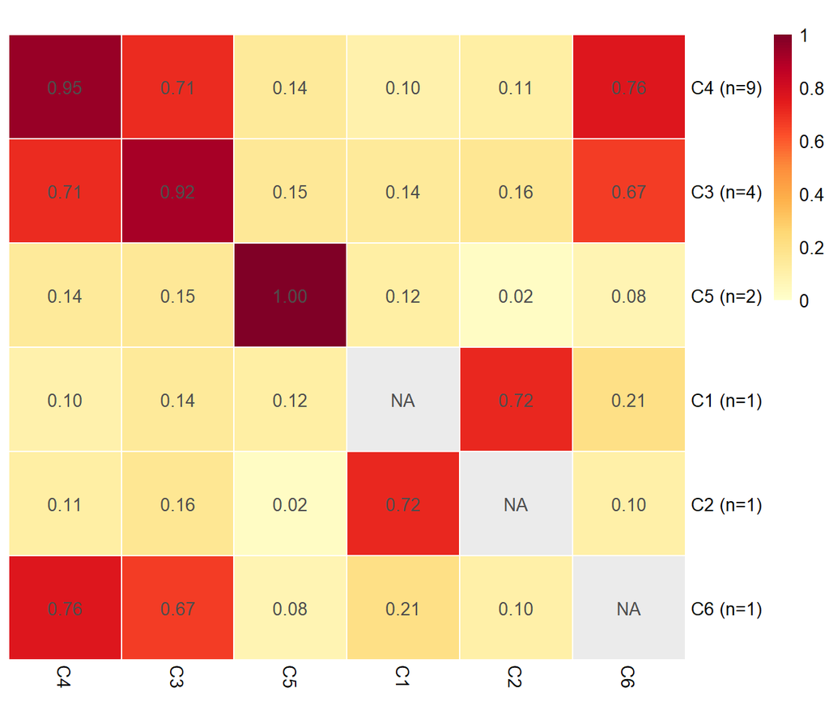

Figura 9. Correlação absoluta média de Spearman dentro de cada cluster (diagonal) e entre clusters (fora da diagonal).

```r
niv <- sort(unique(lab_ref)); gr <- split(seq_along(feat), lab_ref)
Cmed <- matrix(NA_real_, K_REF, K_REF, dimnames = list(paste0("C", niv), paste0("C", niv)))
for (i in seq_len(K_REF)) for (j in seq_len(K_REF)) {
  bloco <- abs(rho[gr[[i]], gr[[j]], drop = FALSE])
  Cmed[i, j] <- if (i == j) { v <- bloco[upper.tri(bloco)]; if (length(v)) mean(v) else NA_real_ }
                else mean(bloco)
}
oc <- order(sapply(gr, length), decreasing = TRUE)
Cmed <- Cmed[oc, oc]
pheatmap(Cmed, display_numbers = TRUE, number_format = "%.2f", fontsize_number = 10,
         color = colorRampPalette(brewer.pal(9, "YlOrRd"))(100), breaks = seq(0, 1, length.out = 101),
         cluster_rows = FALSE, cluster_cols = FALSE, na_col = "grey92", border_color = "white",
         labels_row = paste0("C", niv[oc], " (n=", sapply(gr, length)[oc], ")"), main = "")
```

> A partição tem 6 clusters, dos quais 3 são unitários. A correlação média dentro dos clusters (0,95) é bem maior que entre clusters (0,28), de modo que os grupos representam blocos de informação distintos. Energy e TotalEnergy estão no cluster C3, junto com glszm_ZoneEntropy e gldm_DependenceEntropy. Os descritores de forma que restaram (Elongation e Flatness) ficam isolados, sem redundância com os demais.

# 10. Reprodutibilidade da estrutura

A pergunta é se a partição descreve uma propriedade dos dados ou se é artefato das decisões usadas para construí-la. Perturbam-se separadamente os **dados** (pacientes) e o **método** (correlação, ligação e corte) e comparam-se os efeitos.

## 10.1 Perturbação dos dados

```r
set.seed(SEMENTE)
reamostra <- function(frac, repor, B = B_BOOT) replicate(B, {
  idx <- sample.int(n, size = round(n * frac), replace = repor)
  ari(lab_ref, particao(X[idx, , drop = FALSE]))
})
a_boot  <- reamostra(1.00, TRUE)
a_75    <- reamostra(0.75, FALSE)
a_50    <- reamostra(0.50, FALSE)
a_split <- replicate(B_BOOT, {
  q <- sample.int(n)
  ari(particao(X[q[1:floor(n / 2)], , drop = FALSE]),
      particao(X[q[(floor(n / 2) + 1):n], , drop = FALSE]))
})
resumo_ari <- function(v) sprintf("%.3f [%.3f; %.3f]", mean(v), quantile(v, .025), quantile(v, .975))

tab_ream <- data.frame(
  Perturbação = c(sprintf("Bootstrap (n = %d, com reposição)", n), "Subamostra de 75 %",
                  "Subamostra de 50 %", "Metades disjuntas (split-half)"),
  `n efetivo` = c(n, round(.75 * n), round(.50 * n), floor(n / 2)),
  `ARI médio [IC 95 %]` = c(resumo_ari(a_boot), resumo_ari(a_75), resumo_ari(a_50), resumo_ari(a_split)),
  check.names = FALSE)

kable(tab_ream, format = "html", align = c("l", "c", "c"),
      caption = sprintf("Tabela 20. Reprodutibilidade da partição sob reamostragem de pacientes (%d repetições por cenário)", B_BOOT)) %>%
  kable_styling(bootstrap_options = c("striped", "condensed"), full_width = FALSE)
```

Tabela 20. Reprodutibilidade da partição sob reamostragem de pacientes (300 repetições por cenário)

| Perturbação | n efetivo | ARI médio [IC 95 %] |
| --- | --- | --- |
| Bootstrap (n = 96, com reposição) | 96 | 0.948 [0.741; 1.000] |
| Subamostra de 75 % | 72 | 0.985 [0.741; 1.000] |
| Subamostra de 50 % | 48 | 0.939 [0.741; 1.000] |
| Metades disjuntas (split-half) | 48 | 0.870 [0.541; 1.000] |

> O ARI vale 1 quando as duas partições são idênticas e fica perto de 0 quando a concordância é a esperada ao acaso. No bootstrap, a partição reamostrada concorda com a de referência com ARI médio de 0,948. Nas metades disjuntas, cada partição é estimada com apenas 48 pacientes, e parte da queda (0,870) reflete esse tamanho amostral menor.

## 10.2 Perturbação do método

Toda clusterização de variáveis depende de três decisões raramente relatadas: o coeficiente de correlação, o critério de ligação e o ponto de corte. A análise de multiverso (Steegen et al., 2016) executa todas as combinações defensáveis. Alterar o **corte** muda deliberadamente a granularidade; alterar a **correlação ou a ligação**, mantido o corte, deveria produzir descrições equivalentes do mesmo fenômeno.

```r
multiverso <- expand.grid(distancia = c("spearman", "pearson"),
                          ligacao = c("average", "ward.D2", "complete"),
                          corte = c(0.10, 0.20, 0.30), stringsAsFactors = FALSE)
multiverso$k <- NA_integer_; multiverso$ARI <- NA_real_
for (i in seq_len(nrow(multiverso))) {
  l <- particao(X, multiverso$distancia[i], multiverso$ligacao[i], multiverso$corte[i])
  multiverso$k[i] <- max(l); multiverso$ARI[i] <- ari(lab_ref, l)
}
multiverso$tipo <- ifelse(multiverso$corte == CORTE, "Método (corte fixo)", "Granularidade (corte alterado)")
multiverso <- multiverso[order(-multiverso$ARI), ]

multiverso %>%
  transmute(Correlação = distancia, Ligação = ligacao, `Corte (d)` = corte,
            `N.º de clusters` = k, ARI = round(ARI, 3), `Tipo de decisão` = tipo) %>%
  kable(format = "html", row.names = FALSE, align = c("l", "l", "c", "c", "c", "l"),
        caption = "Tabela 21. Multiverso analítico: ARI de cada configuração contra a partição de referência") %>%
  kable_styling(bootstrap_options = c("striped", "condensed"), full_width = FALSE, font_size = 13)
```

Tabela 21. Multiverso analítico: ARI de cada configuração contra a partição de referência

| Correlação | Ligação | Corte (d) | N.º de clusters | ARI | Tipo de decisão |
| --- | --- | --- | --- | --- | --- |
| spearman | average | 0.2 | 6 | 1.000 | Método (corte fixo) |
| spearman | ward.D2 | 0.3 | 5 | 0.984 | Granularidade (corte alterado) |
| spearman | complete | 0.3 | 5 | 0.984 | Granularidade (corte alterado) |
| pearson | average | 0.3 | 6 | 0.917 | Granularidade (corte alterado) |
| spearman | ward.D2 | 0.2 | 7 | 0.863 | Método (corte fixo) |
| spearman | complete | 0.2 | 7 | 0.863 | Método (corte fixo) |
| spearman | average | 0.1 | 8 | 0.788 | Granularidade (corte alterado) |
| spearman | ward.D2 | 0.1 | 8 | 0.788 | Granularidade (corte alterado) |
| spearman | complete | 0.1 | 8 | 0.788 | Granularidade (corte alterado) |
| pearson | average | 0.2 | 8 | 0.788 | Método (corte fixo) |
| pearson | ward.D2 | 0.2 | 8 | 0.788 | Método (corte fixo) |
| pearson | complete | 0.2 | 8 | 0.788 | Método (corte fixo) |
| pearson | ward.D2 | 0.3 | 7 | 0.772 | Granularidade (corte alterado) |
| pearson | complete | 0.3 | 7 | 0.772 | Granularidade (corte alterado) |
| pearson | average | 0.1 | 9 | 0.645 | Granularidade (corte alterado) |
| pearson | ward.D2 | 0.1 | 9 | 0.645 | Granularidade (corte alterado) |
| pearson | complete | 0.1 | 9 | 0.645 | Granularidade (corte alterado) |
| spearman | average | 0.3 | 3 | 0.403 | Granularidade (corte alterado) |

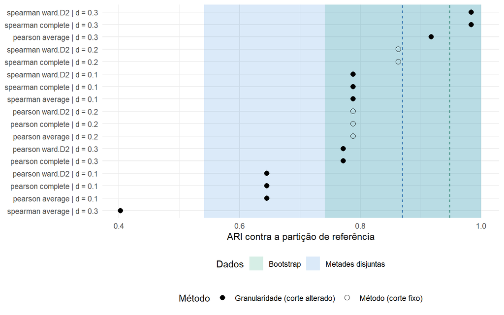

Figura 10. Perturbação dos dados (faixas: intervalos de 95 % do bootstrap e das metades disjuntas) e perturbação do método (pontos).

```r
faixas <- data.frame(
  cenario = factor(c("Bootstrap", "Metades disjuntas"), levels = c("Bootstrap", "Metades disjuntas")),
  lo = c(quantile(a_boot, .025), quantile(a_split, .025)),
  hi = c(quantile(a_boot, .975), quantile(a_split, .975)),
  md = c(mean(a_boot), mean(a_split)))
ggplot() +
  geom_rect(data = faixas, aes(xmin = lo, xmax = hi, ymin = -Inf, ymax = Inf, fill = cenario), alpha = .18) +
  geom_vline(data = faixas, aes(xintercept = md, colour = cenario), linetype = 2, show.legend = FALSE) +
  geom_point(data = subset(multiverso, ARI < 1),
             aes(x = ARI, y = reorder(paste(distancia, ligacao, "| d =", corte), ARI), shape = tipo), size = 2.4) +
  scale_fill_manual(values = c("Bootstrap" = "#1D9E75", "Metades disjuntas" = "#378ADD"), name = "Dados") +
  scale_colour_manual(values = c("Bootstrap" = "#0F6E56", "Metades disjuntas" = "#185FA5")) +
  scale_shape_manual(values = c(16, 1), name = "Método") +
  labs(x = "ARI contra a partição de referência", y = NULL) +
  theme_minimal(base_size = 11) + theme(legend.position = "bottom", legend.box = "vertical")
```

> Mantido o corte em $d =$ 0,20, 1 das 6 combinações de correlação e ligação reproduz exatamente a partição de referência, e a maior divergência corresponde a um ARI de 0,788, valor abaixo do ARI médio do bootstrap (0,948) e dentro da faixa das metades disjuntas. Alterando também o corte, o número de clusters varia de 3 a 9. A comparação entre esses valores e as faixas de reamostragem mostra se as decisões do analista mudam a estrutura mais ou menos do que a própria amostra de pacientes.

## 10.3 Estabilidade de cada cluster (critério de Hennig)

Em cada reamostragem bootstrap, refaz-se o agrupamento e, para cada cluster da referência, procura-se o cluster novo mais parecido, medindo a semelhança pelo Jaccard. A média sobre as reamostragens indica se o cluster se mantém (Hennig, 2007): acima de 0,75, estável; até 0,50, dissolvido.

```r
set.seed(SEMENTE)
cls  <- sort(unique(lab_ref))
Jmat <- matrix(NA_real_, B_BOOT, length(cls))
for (b in seq_len(B_BOOT)) {
  grupos_b <- split(seq_len(p), particao(X[sample.int(n, n, replace = TRUE), , drop = FALSE]))
  for (j in seq_along(cls))
    Jmat[b, j] <- max(vapply(grupos_b, function(g) jaccard(which(lab_ref == cls[j]), g), numeric(1)))
}
hennig <- data.frame(
  Cluster = paste0("C", cls),
  Tamanho = as.integer(table(lab_ref)[as.character(cls)]),
  `J bootstrap` = round(colMeans(Jmat), 3),
  `IC 95 %` = sprintf("[%.2f; %.2f]", apply(Jmat, 2, quantile, .025), apply(Jmat, 2, quantile, .975)),
  check.names = FALSE)
hennig$Situação <- cut(hennig$`J bootstrap`, c(-Inf, .50, .75, Inf),
                       labels = c("Dissolvido", "Intermediário", "Estável"))
hennig <- hennig[order(-hennig$Tamanho), ]

kable(hennig, format = "html", row.names = FALSE, align = c("l", rep("c", 4)),
      caption = sprintf("Tabela 22. Estabilidade de cada cluster sob bootstrap (%d reamostragens)", B_BOOT)) %>%
  kable_styling(bootstrap_options = c("striped", "condensed"), full_width = FALSE)
```

Tabela 22. Estabilidade de cada cluster sob bootstrap (300 reamostragens)

| Cluster | Tamanho | J bootstrap | IC 95 % | Situação |
| --- | --- | --- | --- | --- |
| C4 | 9 | 0.962 | [0.80; 1.00] | Estável |
| C3 | 4 | 0.988 | [1.00; 1.00] | Estável |
| C5 | 2 | 1.000 | [1.00; 1.00] | Estável |
| C1 | 1 | 0.968 | [0.50; 1.00] | Estável |
| C2 | 1 | 0.968 | [0.50; 1.00] | Estável |
| C6 | 1 | 0.833 | [0.10; 1.00] | Estável |

> 6 clusters foram classificados como estáveis, 0 como intermediários e 0 como dissolvidos. Em clusters de um único descritor, o Jaccard é 1 apenas quando o descritor permanece sozinho na partição reamostrada.

## 10.4 A estrutura depende do diagnóstico ou do protocolo?

Se a forma como os descritores se correlacionam fosse diferente entre pulmão e colorretal, ou entre exames com e sem contraste, não faria sentido usar uma única partição para todos os pacientes. Para cada fator, agrupam-se os descritores separadamente em cada grupo e comparam-se as duas partições pelo ARI. A referência é a distribuição do ARI quando os pacientes são divididos ao acaso em grupos de mesmo tamanho. O teste é unilateral, pois apenas uma concordância **menor** que a do acaso indicaria dependência.

```r
set.seed(SEMENTE)
controle <- function(g) {
  n1 <- sum(g)
  obs <- ari(particao(X[g == 1, , drop = FALSE]), particao(X[g == 0, , drop = FALSE]))
  nulo <- replicate(B_BOOT, {
    q <- sample.int(n)
    ari(particao(X[q[1:n1], , drop = FALSE]), particao(X[q[(n1 + 1):n], , drop = FALSE]))
  })
  list(obs = obs, nulo = nulo, n1 = n1, p = (1 + sum(nulo <= obs)) / (B_BOOT + 1))
}
c_dx <- controle(y); c_ct <- controle(ct)

tab_ctrl <- data.frame(
  Fator = c("Diagnóstico (pulmão vs. colorretal)", "Protocolo (com vs. sem contraste)"),
  `Tamanho dos grupos` = c(sprintf("%d / %d", c_dx$n1, n - c_dx$n1), sprintf("%d / %d", c_ct$n1, n - c_ct$n1)),
  `ARI observado` = round(c(c_dx$obs, c_ct$obs), 3),
  `ARI nulo [IC 95 %]` = c(resumo_ari(c_dx$nulo), resumo_ari(c_ct$nulo)),
  `p empírico (unilateral)` = round(c(c_dx$p, c_ct$p), 3),
  check.names = FALSE)

kable(tab_ctrl, format = "html", align = c("l", rep("c", 4)),
      caption = sprintf("Tabela 23. Dependência da estrutura em relação ao diagnóstico e ao protocolo (%d divisões aleatórias)", B_BOOT)) %>%
  kable_styling(bootstrap_options = c("striped", "condensed"), full_width = FALSE)
```

Tabela 23. Dependência da estrutura em relação ao diagnóstico e ao protocolo (300 divisões aleatórias)

| Fator | Tamanho dos grupos | ARI observado | ARI nulo [IC 95 %] | p empírico (unilateral) |
| --- | --- | --- | --- | --- |
| Diagnóstico (pulmão vs. colorretal) | 54 / 42 | 0.863 | 0.865 [0.536; 1.000] | 0.452 |
| Protocolo (com vs. sem contraste) | 56 / 40 | 0.937 | 0.864 [0.536; 1.000] | 0.595 |

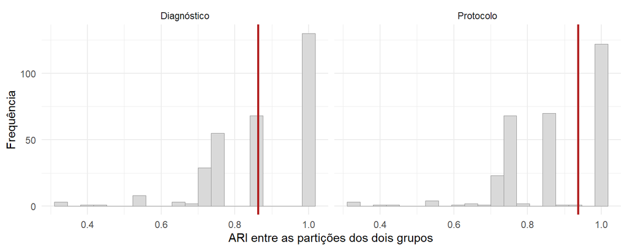

Figura 11. Distribuição do ARI em divisões aleatórias dos pacientes (histogramas) e valor observado em cada fator (linha vermelha).

```r
data.frame(valor = c(c_dx$nulo, c_ct$nulo),
           fator = rep(c("Diagnóstico", "Protocolo"), each = B_BOOT)) %>%
  ggplot(aes(valor)) +
  geom_histogram(bins = 20, fill = "grey85", colour = "grey55", linewidth = .3) +
  geom_vline(data = data.frame(fator = c("Diagnóstico", "Protocolo"), obs = c(c_dx$obs, c_ct$obs)),
             aes(xintercept = obs), colour = "firebrick", linewidth = .9) +
  facet_wrap(~ fator) +
  labs(x = "ARI entre as partições dos dois grupos", y = "Frequência") +
  theme_minimal(base_size = 11)
```

> Diagnóstico: ARI observado de 0,863, contra média nula de 0,865 (p = 0,452). Protocolo: ARI observado de 0,937, contra média nula de 0,864 (p = 0,595). Em nenhum dos dois casos há evidência de que a estrutura dependa do fator, o que sustenta o uso de uma única partição para todos os pacientes.

# 11. Clusters e frequência de seleção

Esta seção liga o agrupamento à seleção da Seção 8. Para cada cluster, calcula-se a proporção dos 50 ajustes em que **ao menos um** de seus descritores esteve entre os $k =$ 5 mais importantes. Como clusters grandes têm mais chances de serem atingidos, a tabela inclui a frequência esperada se os 5 descritores fossem sorteados ao acaso:

$$P(\text{cluster com } m \text{
descritores ser atingido}) = 1 - \binom{p - m}{k} \Big/
\binom{p}{k}.$$

```r
sel_k <- t(apply(rf$imp, 1, function(v) {
  o <- order(v, decreasing = TRUE)[seq_len(TOP_K)]; o <- o[v[o] > 0]
  seq_along(v) %in% o
}))
tab_fc <- data.frame(
  Cluster = paste0("C", ordem),
  Tamanho = as.integer(table(lab_ref)[as.character(ordem)]),
  Descritores = sapply(ordem, function(cc) paste(nome(feat[lab_ref == cc]), collapse = ", ")),
  `Frequência do cluster` = sapply(ordem, function(cc) mean(apply(sel_k[, lab_ref == cc, drop = FALSE], 1, any))),
  `Esperado ao acaso` = sapply(ordem, function(cc) {
    m <- sum(lab_ref == cc); 1 - choose(p - m, TOP_K) / choose(p, TOP_K) }),
  `Maior frequência individual` = sapply(ordem, function(cc) max(colMeans(sel_k[, lab_ref == cc, drop = FALSE]))),
  check.names = FALSE, row.names = NULL)
tab_fc$`Diferença` <- tab_fc$`Frequência do cluster` - tab_fc$`Esperado ao acaso`

tab_fc %>%
  mutate(across(c(`Frequência do cluster`, `Esperado ao acaso`, `Maior frequência individual`), ~ pct(.x)),
         `Diferença` = sprintf("%+.0f p.p.", 100 * `Diferença`)) %>%
  kable(format = "html", row.names = FALSE, align = c("l", "c", "l", rep("c", 4)),
        caption = sprintf("Tabela 24. Frequência de seleção por cluster (k = %d), comparada à esperada ao acaso", TOP_K)) %>%
  kable_styling(bootstrap_options = c("striped", "condensed"), font_size = 13) %>%
  column_spec(3, width = "35%")
```

Tabela 24. Frequência de seleção por cluster (k = 5), comparada à esperada ao acaso

| Cluster | Tamanho | Descritores | Frequência do cluster | Esperado ao acaso | Maior frequência individual | Diferença |
| --- | --- | --- | --- | --- | --- | --- |
| C4 | 9 | firstorder_Range, glcm_Autocorrelation, glcm_JointAverage, glrlm_HighGrayLevelRunEmphasis, glrlm_LongRunHighGrayLevelEmphasis, glrlm_ShortRunHighGrayLevelEmphasis, glszm_HighGrayLevelZoneEmphasis, gld… | 86 % | 99 % | 50 % | -13 p.p. |
| C3 | 4 | firstorder_Energy, firstorder_TotalEnergy, glszm_ZoneEntropy, gldm_DependenceEntropy | 100 % | 77 % | 100 % | +23 p.p. |
| C5 | 2 | glszm_SizeZoneNonUniformityNormalized, glszm_SmallAreaEmphasis | 22 % | 49 % | 16 % | -27 p.p. |
| C1 | 1 | shape_Elongation | 6 % | 28 % | 6 % | -22 p.p. |
| C2 | 1 | shape_Flatness | 6 % | 28 % | 6 % | -22 p.p. |
| C6 | 1 | gldm_LargeDependenceHighGrayLevelEmphasis | 24 % | 28 % | 24 % | -4 p.p. |

> Um cluster grande aparece com frequência alta mesmo sem nenhuma preferência do modelo: o maior cluster (C4, 9 descritores) seria atingido ao acaso em 99 % dos ajustes, e foi atingido em 86 %. A comparação relevante, portanto, é entre a frequência observada e a esperada. Ficaram claramente acima do acaso: C3 (100 % contra 77 %). Essa linha de base será usada também na avaliação da estabilidade da seleção nos níveis de descritor e de cluster.

# 12. Estabilidade da seleção: descritor e cluster

## 12.1 Método

A estabilidade da seleção mede se o modelo escolhe os mesmos descritores quando os dados mudam um pouco. Em cada um dos 50 ajustes do Random Forest da Seção 8, o conjunto selecionado é formado pelos $k$ descritores de maior importância (com importância positiva). Os mesmos ajustes são lidos de duas maneiras:

- **Nível de descritor:** compara-se quais descritores foram selecionados.
- **Nível de cluster:** cada descritor selecionado é substituído pelo seu cluster (Seção 9), e compara-se quais clusters foram representados.

Nada no modelo muda; muda apenas a unidade em que a seleção é lida. Se parte da instabilidade for troca entre descritores redundantes, a seleção será mais consistente no nível de cluster.

Duas medidas são usadas. O **índice de Jaccard** compara dois conjuntos (elementos em comum divididos pelo total de elementos distintos); em cada semente, calcula-se a média do Jaccard entre os 5 ajustes, e as 10 sementes funcionam como réplicas pareadas. O **índice $\Phi$ de Nogueira** resume a estabilidade dos 50 ajustes de uma vez, a partir da variância das indicadoras de seleção de cada descritor (Nogueira, Sechidis e Brown, 2018):

$$\hat{\Phi} = 1 -
\frac{\frac{1}{p}\sum_{f=1}^{p} s_f^2}{\frac{\bar{k}}{p}\left(1 -
\frac{\bar{k}}{p}\right)}.$$

Ambos valem 1 quando todos os ajustes selecionam o mesmo conjunto.

```r
# Indicadoras de seleção: 1 = entre os k mais importantes (com importância positiva)
bin_variaveis <- function(imp, k) {
  t(apply(imp, 1, function(v) {
    o <- order(v, decreasing = TRUE)[seq_len(min(k, length(v)))]; o <- o[v[o] > 0]
    as.numeric(seq_along(v) %in% o)
  }))
}
# 1 = cluster representado entre os k descritores selecionados
bin_clusters <- function(imp, k, mapa = lab_ref) {
  niv <- sort(unique(mapa)); Zv <- bin_variaveis(imp, k)
  t(apply(Zv, 1, function(r) as.numeric(niv %in% unique(mapa[r == 1]))))
}
# Média do Jaccard entre todos os pares de linhas
jaccard_medio_bin <- function(Z) {
  I <- Z %*% t(Z); tam <- rowSums(Z); U <- outer(tam, tam, "+") - I
  J <- ifelse(U > 0, I / pmax(U, 1), 1); mean(J[upper.tri(J)])
}
# Phi de Nogueira para M conjuntos
phi_nogueira <- function(Z) {
  pz <- ncol(Z); kb <- mean(rowSums(Z))
  if (kb == 0 || kb == pz) return(NA_real_)
  1 - mean(apply(Z, 2, var)) / ((kb / pz) * (1 - kb / pz))
}
# Jaccard médio calculado dentro de cada semente
por_semente <- function(Z, seed_fit)
  sapply(sort(unique(seed_fit)), function(s) jaccard_medio_bin(Z[seed_fit == s, , drop = FALSE]))
```

## 12.2 Estabilidade observada

```r
tab_k <- do.call(rbind, lapply(K_GRID, function(k) {
  Zv <- bin_variaveis(rf$imp, k); Zc <- bin_clusters(rf$imp, k)
  jv <- por_semente(Zv, rf$seed_fit); jc <- por_semente(Zc, rf$seed_fit)
  ic <- ic_t(jc - jv)
  wx <- tryCatch(suppressWarnings(wilcox.test(jc, jv, paired = TRUE)$p.value), error = function(e) NA_real_)
  data.frame(k = k, `J descritor` = mean(jv), `J cluster` = mean(jc), Ganho = mean(jc - jv),
             `IC 95 % do ganho` = sprintf("[%.3f; %.3f]", ic[1], ic[2]), `p (Wilcoxon)` = wx,
             `Phi descritor` = phi_nogueira(Zv), `Phi cluster` = phi_nogueira(Zc), check.names = FALSE)
}))

tab_k %>%
  mutate(across(c(`J descritor`, `J cluster`, Ganho, `Phi descritor`, `Phi cluster`), ~ round(.x, 3)),
         `p (Wilcoxon)` = format.pval(`p (Wilcoxon)`, digits = 2, eps = .001)) %>%
  kable(format = "html", row.names = FALSE, align = "c",
        caption = sprintf("Tabela 25. Estabilidade da seleção por tamanho do conjunto (%d sementes como réplicas pareadas)", N_SEEDS)) %>%
  kable_styling(bootstrap_options = c("striped", "condensed"), full_width = FALSE)
```

Tabela 25. Estabilidade da seleção por tamanho do conjunto (10 sementes como réplicas pareadas)

| k | J descritor | J cluster | Ganho | IC 95 % do ganho | p (Wilcoxon) | Phi descritor | Phi cluster |
| --- | --- | --- | --- | --- | --- | --- | --- |
| 3 | 0.574 | 0.578 | 0.004 | [-0.037; 0.046] | 0.957 | 0.661 | 0.607 |
| 5 | 0.449 | 0.662 | 0.212 | [0.130; 0.294] | 0.002 | 0.482 | 0.586 |
| 7 | 0.448 | 0.656 | 0.208 | [0.145; 0.271] | 0.002 | 0.390 | 0.564 |

> Em $k =$ 5, o Jaccard passa de 0,449 no nível de descritor para 0,662 no nível de cluster, e o $\Phi$, de 0,482 para 0,586. Lida por cluster, a seleção parece mais consistente. O p-valor do Wilcoxon indica apenas que o sinal do ganho se repete entre as sementes; com 10 pares na mesma direção, o menor valor possível é 0,002.

## 12.3 Comparação com o acaso

Com poucos clusters, e um deles com metade dos descritores, até seleções sorteadas ao acaso coincidem bastante no nível de cluster. Por isso, cada índice é comparado ao valor esperado se os $k$ descritores fossem sorteados uniformemente, com os tamanhos reais dos clusters. O valor ajustado,

$$\text{ajustado} = \frac{\text{observado}
- \text{acaso}}{1 - \text{acaso}},$$

indica que fração da distância entre o acaso e a concordância perfeita é percorrida pela seleção observada.

```r
sorteia_Z <- function(k, mapa, M) {
  pt <- length(mapa); niv <- sort(unique(mapa))
  Zv <- matrix(0, M, pt); Zc <- matrix(0, M, length(niv))
  for (m in seq_len(M)) {
    s <- sample.int(pt, min(k, pt)); Zv[m, s] <- 1
    Zc[m, match(unique(mapa[s]), niv)] <- 1
  }
  list(v = Zv, c = Zc)
}
set.seed(SEMENTE)
acaso <- t(sapply(K_GRID, function(k) {
  jj <- replicate(B_ACASO, { z <- sorteia_Z(k, lab_ref, N_FOLDS)
                             c(jaccard_medio_bin(z$v), jaccard_medio_bin(z$c)) })
  pp <- replicate(B_ACASO_PHI, { z <- sorteia_Z(k, lab_ref, N_SEEDS * N_FOLDS)
                                 c(phi_nogueira(z$v), phi_nogueira(z$c)) })
  c(Jv = mean(jj[1, ]), Jc = mean(jj[2, ]), Pv = mean(pp[1, ], na.rm = TRUE), Pc = mean(pp[2, ], na.rm = TRUE))
}))
```

```r
ajusta <- function(obs, ac) (obs - ac) / (1 - ac)
tab_acaso <- data.frame(
  k = K_GRID,
  `J descritor (acaso)` = acaso[, "Jv"], `J cluster (acaso)` = acaso[, "Jc"],
  `J descritor ajustado` = ajusta(tab_k$`J descritor`, acaso[, "Jv"]),
  `J cluster ajustado` = ajusta(tab_k$`J cluster`, acaso[, "Jc"]),
  `Phi cluster (acaso)` = acaso[, "Pc"],
  `Phi descritor ajustado` = ajusta(tab_k$`Phi descritor`, acaso[, "Pv"]),
  `Phi cluster ajustado` = ajusta(tab_k$`Phi cluster`, acaso[, "Pc"]),
  check.names = FALSE)

tab_acaso %>%
  mutate(across(-k, ~ round(.x, 3))) %>%
  kable(format = "html", row.names = FALSE, align = "c",
        caption = sprintf("Tabela 26. Linha de base do acaso e índices ajustados (%d sorteios para o Jaccard e %d para o Phi)", B_ACASO, B_ACASO_PHI)) %>%
  kable_styling(bootstrap_options = c("striped", "condensed"), full_width = FALSE)
```

Tabela 26. Linha de base do acaso e índices ajustados (2000 sorteios para o Jaccard e 200 para o Phi)

| k | J descritor (acaso) | J cluster (acaso) | J descritor ajustado | J cluster ajustado | Phi cluster (acaso) | Phi descritor ajustado | Phi cluster ajustado |
| --- | --- | --- | --- | --- | --- | --- | --- |
| 3 | 0.106 | 0.444 | 0.524 | 0.242 | 0.309 | 0.661 | 0.431 |
| 5 | 0.176 | 0.520 | 0.332 | 0.296 | 0.304 | 0.482 | 0.405 |
| 7 | 0.251 | 0.574 | 0.263 | 0.191 | 0.266 | 0.389 | 0.406 |

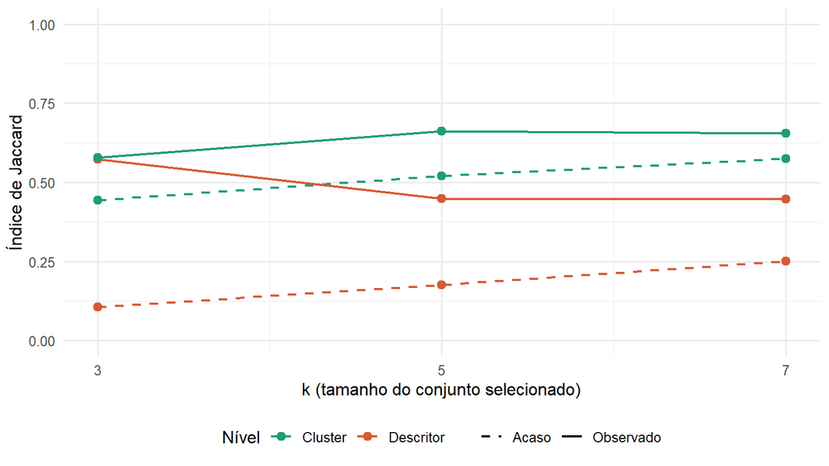

Figura 12. Jaccard observado (linhas cheias) e esperado ao acaso (linhas tracejadas), nos níveis de descritor e de cluster.

```r
rbind(data.frame(k = K_GRID, valor = tab_k$`J descritor`, nivel = "Descritor", tipo = "Observado"),
      data.frame(k = K_GRID, valor = tab_k$`J cluster`,   nivel = "Cluster",   tipo = "Observado"),
      data.frame(k = K_GRID, valor = acaso[, "Jv"],       nivel = "Descritor", tipo = "Acaso"),
      data.frame(k = K_GRID, valor = acaso[, "Jc"],       nivel = "Cluster",   tipo = "Acaso")) %>%
  ggplot(aes(k, valor, colour = nivel, linetype = tipo)) +
  geom_line(linewidth = .8) + geom_point(size = 2.4) +
  scale_colour_manual(values = c("Cluster" = "#1D9E75", "Descritor" = "#D85A30"), name = "Nível") +
  scale_linetype_manual(values = c("Observado" = 1, "Acaso" = 2), name = NULL) +
  scale_x_continuous(breaks = K_GRID) + ylim(0, 1) +
  labs(x = "k (tamanho do conjunto selecionado)", y = "Índice de Jaccard") +
  theme_minimal(base_size = 12) + theme(legend.position = "bottom")
```

> Em $k =$ 5, o Jaccard esperado ao acaso é de 0,176 no nível de descritor e de 0,520 no nível de cluster. Descontado o acaso de cada nível, o Jaccard ajustado é de 0,332 para os descritores e de 0,296 para os clusters; o $\Phi$ ajustado, de 0,482 e 0,405. Portanto, o aumento aparente de estabilidade no nível de cluster desaparece quando se desconta o acaso: ele decorre de a unidade cluster ser mais grosseira, e não de uma seleção mais consistente.

## 12.4 Teste de aleatorização do rótulo

O teste verifica se a estabilidade observada depende da relação entre os descritores e o diagnóstico. Os diagnósticos são embaralhados entre os pacientes, o que destrói essa relação mas preserva a correlação entre os descritores, e a análise é repetida 200 vezes. Para tornar o procedimento viável, cada repetição usa 5 sementes e o `mtry` fixo no valor mais escolhido na Seção 8; o cenário observado de referência é recalculado com a mesma configuração, de modo que observado e nulo são diretamente comparáveis.

```r
MTRY_MODAL <- as.integer(names(sort(table(rf$mtry), decreasing = TRUE))[1])

roda_rf_fixo <- function(yy, estratos, seeds = N_SEEDS_PERM, mt = MTRY_MODAL) {
  imp <- matrix(NA_real_, seeds * N_FOLDS, p); seed_fit <- integer(seeds * N_FOLDS)
  oof <- matrix(NA_real_, seeds, n); linha <- 0
  for (s in seq_len(seeds)) {
    set.seed(1000 + s)
    for (te in caret::createFolds(estratos, k = N_FOLDS, list = TRUE)) {
      linha <- linha + 1; seed_fit[linha] <- s; tr <- setdiff(seq_len(n), te)
      set.seed(3000 + linha)
      m <- randomForest(X[tr, ], factor(yy[tr]), ntree = NTREE, mtry = mt, importance = TRUE)
      imp[linha, ] <- importance(m, type = 1)[, 1]
      oof[s, te] <- predict(m, X[te, ], type = "prob")[, "1"]
    }
  }
  list(imp = imp, seed_fit = seed_fit,
       auc = mean(apply(oof, 1, function(pp)
         as.numeric(auc(roc(yy, pp, direction = "<", levels = c(0, 1), quiet = TRUE))))))
}
estatisticas <- function(r) {
  jv <- mean(por_semente(bin_variaveis(r$imp, TOP_K), r$seed_fit))
  jc <- mean(por_semente(bin_clusters(r$imp, TOP_K), r$seed_fit))
  c(AUC = r$auc, Jv = jv, Jc = jc, Ganho = jc - jv)
}

obs_vec  <- estatisticas(roda_rf_fixo(y, estrato))
perm_mat <- t(sapply(seq_len(B_PERM), function(b) {
  set.seed(5000 + b); yp <- sample(y)
  estatisticas(roda_rf_fixo(yp, factor(paste0(yp, "_", ct))))
}))
```

```r
p_perm <- sapply(names(obs_vec), function(nm) (1 + sum(perm_mat[, nm] >= obs_vec[nm])) / (B_PERM + 1))
tab_perm <- data.frame(
  Estatística = c("AUC (out-of-fold)", "J descritor", "J cluster", "Ganho (cluster menos descritor)"),
  Observado = round(unname(obs_vec), 3),
  `Nulo (média)` = round(unname(colMeans(perm_mat)), 3),
  `Nulo (IC 95 %)` = sprintf("[%.3f; %.3f]", apply(perm_mat, 2, quantile, .025), apply(perm_mat, 2, quantile, .975)),
  Excesso = round(unname(obs_vec - colMeans(perm_mat)), 3),
  `p empírico` = format.pval(unname(p_perm), digits = 2, eps = 1 / (B_PERM + 1)),
  check.names = FALSE, row.names = NULL)

kable(tab_perm, format = "html", row.names = FALSE, align = c("l", rep("c", 5)),
      caption = sprintf("Tabela 27. Teste de aleatorização do rótulo (%d permutações; %d sementes; mtry = %d; k = %d)",
                        B_PERM, N_SEEDS_PERM, MTRY_MODAL, TOP_K)) %>%
  kable_styling(bootstrap_options = c("striped", "condensed"), full_width = FALSE)
```

Tabela 27. Teste de aleatorização do rótulo (200 permutações; 5 sementes; mtry = 4; k = 5)

| Estatística | Observado | Nulo (média) | Nulo (IC 95 %) | Excesso | p empírico |
| --- | --- | --- | --- | --- | --- |
| AUC (out-of-fold) | 0.721 | 0.493 | [0.376; 0.619] | 0.228 | 0.005 |
| J descritor | 0.440 | 0.279 | [0.118; 0.446] | 0.162 | 0.035 |
| J cluster | 0.702 | 0.523 | [0.291; 0.760] | 0.179 | 0.060 |
| Ganho (cluster menos descritor) | 0.262 | 0.245 | [0.065; 0.420] | 0.017 | 0.418 |

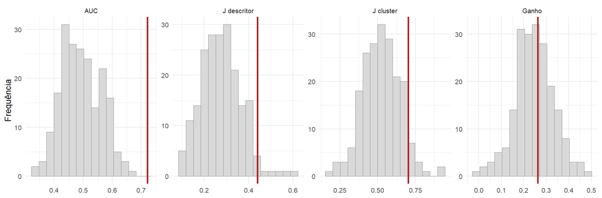

Figura 13. Distribuição nula de cada estatística sob permutação do diagnóstico (histogramas) e valor observado (linha vermelha).

```r
rot <- c("AUC", "J descritor", "J cluster", "Ganho")
data.frame(valor = as.vector(perm_mat), est = factor(rep(rot, each = B_PERM), levels = rot)) %>%
  ggplot(aes(valor)) +
  geom_histogram(bins = 16, fill = "grey85", colour = "grey55", linewidth = .3) +
  geom_vline(data = data.frame(est = factor(rot, levels = rot), obs = unname(obs_vec)),
             aes(xintercept = obs), colour = "firebrick", linewidth = .9) +
  facet_wrap(~ est, scales = "free", nrow = 1) +
  labs(x = NULL, y = "Frequência") + theme_minimal(base_size = 10)
```

> A AUC observada (0,721) supera a distribuição nula (média 0,493, p = 0,005): o modelo tem sinal real. No nível de descritor, o Jaccard observado é de 0,440, contra 0,279 sob o nulo (p = 0,035); no nível de cluster, 0,702 contra 0,523 (p = 0,060). O ganho de ler a seleção por cluster é de 0,262, contra 0,245 com diagnósticos embaralhados (p = 0,418). O ganho não difere do que se obtém sem nenhuma relação com o diagnóstico: ele decorre da redundância entre os descritores e do pequeno número de clusters, e não do sinal da doença.

# 13. Comparação: modelo base e modelos radiômicos

## 13.1 Modelos comparados

Todos os modelos são avaliados nas mesmas 10 repetições e nas mesmas partições da validação cruzada, de modo que cada semente produz uma AUC para cada modelo nos mesmos pacientes.

1. **Modelo base:** regressão logística com a esfericidade (Seção 5).
2. **Random Forest:** os 18 descritores lapidados (Seção 8).
3. **Modelo de clusters:** regressão logística com um representante de cada cluster da Seção 9, o medoide, isto é, o descritor mais próximo dos demais do seu grupo. Cada cluster contribui com uma variável, o que mantém o modelo interpretável.
4. **Modelo base mais clusters:** a esfericidade junto com os medoides. A comparação com o modelo base indica se a radiômica lapidada acrescenta informação à medida de irregularidade da borda.

Descritores estritamente positivos e muito assimétricos (assimetria acima de 1) entram em escala logarítmica.

```r
Dm_ref  <- as.matrix(dist_ref(X))
med_idx <- sapply(sort(unique(lab_ref)), function(cc) {
  idx <- which(lab_ref == cc)
  if (length(idx) == 1) idx else idx[which.min(rowMeans(Dm_ref[idx, idx, drop = FALSE]))]
})
assimetria <- function(v) mean((v - mean(v))^3) / sd(v)^3
transforma <- function(v) if (all(v > 0) && abs(assimetria(v)) > 1) log(v) else v

Z_clu <- as.data.frame(lapply(med_idx, function(j) transforma(X[, j])))
names(Z_clu) <- make.names(nome(feat[med_idx]))

data.frame(Cluster = paste0("C", sort(unique(lab_ref))),
           Medoide = nome(feat[med_idx]),
           `Escala no modelo` = sapply(med_idx, function(j)
             if (all(X[, j] > 0) && abs(assimetria(X[, j])) > 1) "logaritmo" else "original"),
           check.names = FALSE) %>%
  kable(format = "html", row.names = FALSE, align = c("l", "l", "c"),
        caption = "Tabela 28. Representante (medoide) de cada cluster") %>%
  kable_styling(bootstrap_options = c("striped", "condensed"), full_width = FALSE)
```

Tabela 28. Representante (medoide) de cada cluster

| Cluster | Medoide | Escala no modelo |
| --- | --- | --- |
| C1 | shape_Elongation | original |
| C2 | shape_Flatness | original |
| C3 | firstorder_Energy | logaritmo |
| C4 | glrlm_ShortRunHighGrayLevelEmphasis | original |
| C5 | glszm_SizeZoneNonUniformityNormalized | original |
| C6 | gldm_LargeDependenceHighGrayLevelEmphasis | logaritmo |

## 13.2 Desempenho

```r
auc_clu    <- cv_logit(Z_clu)
auc_base_c <- cv_logit(cbind(esfericidade = esf_base, Z_clu))

modelos <- list(
  "Modelo base: esfericidade (logística)"          = auc_base,
  "Random Forest: 18 descritores lapidados"        = rf$auc_semente,
  "Modelo de clusters: 6 medoides (logística)"     = auc_clu,
  "Modelo base + clusters (logística)"             = auc_base_c)

tab_comp_mod <- do.call(rbind, lapply(names(modelos), function(nm) {
  a <- modelos[[nm]]; d <- a - auc_base; ic <- ic_t(d)
  data.frame(Modelo = nm, Variáveis = c(1, p, length(med_idx), length(med_idx) + 1)[match(nm, names(modelos))],
             `AUC média` = round(mean(a), 3), `Desvio padrão` = round(sd(a), 3),
             `Diferença para o modelo base [IC 95 %]` =
               if (identical(a, auc_base)) "" else sprintf("%+.3f [%+.3f; %+.3f]", mean(d), ic[1], ic[2]),
             `Sementes em que supera o base` =
               if (identical(a, auc_base)) "" else sprintf("%d de %d", sum(d > 0), N_SEEDS),
             check.names = FALSE)
}))

kable(tab_comp_mod, format = "html", row.names = FALSE, align = c("l", rep("c", 5)),
      caption = sprintf("Tabela 29. Comparação dos modelos (AUC out-of-fold por semente, %d sementes, mesmas partições)", N_SEEDS)) %>%
  kable_styling(bootstrap_options = c("striped", "condensed"), full_width = FALSE) %>%
  row_spec(1, bold = TRUE)
```

Tabela 29. Comparação dos modelos (AUC out-of-fold por semente, 10 sementes, mesmas partições)

| Modelo | Variáveis | AUC média | Desvio padrão | Diferença para o modelo base [IC 95 %] | Sementes em que supera o base |
| --- | --- | --- | --- | --- | --- |
| Modelo base: esfericidade (logística) | 1 | 0.797 | 0.003 |  |  |
| Random Forest: 18 descritores lapidados | 18 | 0.729 | 0.021 | -0.069 [-0.083; -0.055] | 0 de 10 |
| Modelo de clusters: 6 medoides (logística) | 6 | 0.729 | 0.010 | -0.069 [-0.076; -0.061] | 0 de 10 |
| Modelo base + clusters (logística) | 7 | 0.770 | 0.014 | -0.028 [-0.038; -0.017] | 0 de 10 |

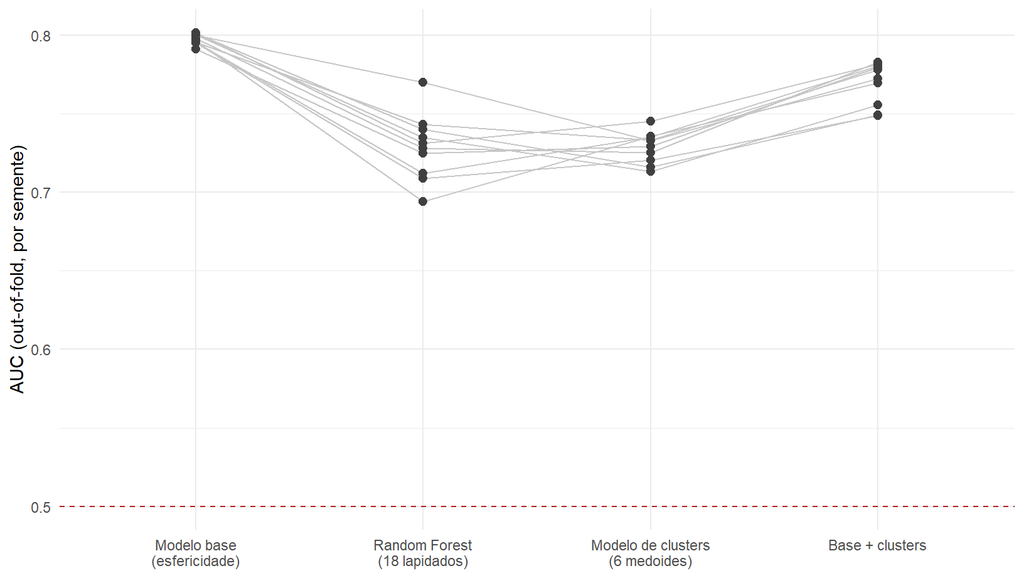

Figura 14. AUC de cada semente nos quatro modelos. As linhas ligam as AUCs obtidas na mesma semente, isto é, nas mesmas partições. A linha vermelha marca o acaso.

```r
niv_m <- c("Modelo base\n(esfericidade)", "Random Forest\n(18 lapidados)",
           "Modelo de clusters\n(6 medoides)", "Base + clusters")
data.frame(semente = rep(seq_len(N_SEEDS), 4),
           auc = c(auc_base, rf$auc_semente, auc_clu, auc_base_c),
           modelo = factor(rep(niv_m, each = N_SEEDS), levels = niv_m)) %>%
  ggplot(aes(modelo, auc, group = semente)) +
  geom_line(colour = "grey78") + geom_point(size = 2.2, colour = "grey25") +
  geom_hline(yintercept = .5, linetype = 2, colour = "firebrick") +
  labs(x = NULL, y = "AUC (out-of-fold, por semente)") +
  theme_minimal(base_size = 11)
```

## 13.3 O que cada cluster acrescenta ao modelo base

Para identificar qual informação radiômica, se alguma, complementa a irregularidade da borda, cada medoide é acrescentado isoladamente ao modelo base.

```r
cl_ord <- sort(unique(lab_ref))
tab_inc <- do.call(rbind, lapply(seq_along(med_idx), function(i) {
  a  <- cv_logit(data.frame(esfericidade = esf_base, z = Z_clu[[i]]))
  dd <- a - auc_base; ic <- ic_t(dd)
  data.frame(Cluster = paste0("C", cl_ord[i]),
             `Informação` = nome(feat[med_idx[i]]),
             `AUC base + cluster` = round(mean(a), 3),
             `Ganho sobre o base [IC 95 %]` = sprintf("%+.3f [%+.3f; %+.3f]", mean(dd), ic[1], ic[2]),
             `Sementes com ganho` = sprintf("%d de %d", sum(dd > 0), N_SEEDS),
             ganho = mean(dd), lo = ic[1], check.names = FALSE)
}))
tab_inc <- tab_inc[order(-tab_inc$ganho), ]

kable(tab_inc[, 1:5], format = "html", row.names = FALSE, align = c("l", "l", "c", "c", "c"),
      caption = sprintf("Tabela 30. Ganho de AUC ao acrescentar cada cluster ao modelo base (AUC do modelo base: %.3f)", mean(auc_base))) %>%
  kable_styling(bootstrap_options = c("striped", "condensed"), full_width = FALSE)
```

Tabela 30. Ganho de AUC ao acrescentar cada cluster ao modelo base (AUC do modelo base: 0.797)

| Cluster | Informação | AUC base + cluster | Ganho sobre o base [IC 95 %] | Sementes com ganho |
| --- | --- | --- | --- | --- |
| C6 | gldm_LargeDependenceHighGrayLevelEmphasis | 0.811 | +0.014 [+0.010; +0.017] | 10 de 10 |
| C4 | glrlm_ShortRunHighGrayLevelEmphasis | 0.807 | +0.009 [+0.006; +0.013] | 9 de 10 |
| C3 | firstorder_Energy | 0.801 | +0.004 [-0.001; +0.008] | 8 de 10 |
| C2 | shape_Flatness | 0.800 | +0.003 [-0.002; +0.007] | 7 de 10 |
| C1 | shape_Elongation | 0.786 | -0.011 [-0.014; -0.008] | 0 de 10 |
| C5 | glszm_SizeZoneNonUniformityNormalized | 0.786 | -0.011 [-0.016; -0.006] | 0 de 10 |

> **Modelo base contra os modelos radiômicos.** A regressão logística com uma única medida de irregularidade da borda (AUC 0,797) supera o Random Forest com os 18 descritores lapidados (0,729), em 10 das 10 sementes. O modelo com um representante de cada cluster alcança 0,729.

> **Valor incremental.** Acrescentar os 6 medoides ao modelo base leva a AUC a 0,770, uma diferença de -0,028 em relação ao modelo base. Isoladamente, o cluster que mais acrescenta é o C6 (gldm_LargeDependenceHighGrayLevelEmphasis), com ganho médio de +0,014. O intervalo de confiança do ganho fica inteiramente acima de zero para: C6, C4.

> Ou seja, juntar todos os clusters piora o modelo, provavelmente por sobreajuste, mas alguns clusters isolados trazem um ganho pequeno e consistente sobre a irregularidade da borda.

> **Cuidados.** Os intervalos refletem a variação entre partições dos mesmos 96 pacientes, e não a incerteza amostral. O modelo base mais clusters tem 7 preditores para cerca de 34 pacientes colorretais em cada treino, o que favorece o sobreajuste.

# 14. Exportação

```r
dir.create("resultados_analise", showWarnings = FALSE)
write.csv(efeito,   "resultados_analise/efeito_contraste_105.csv", row.names = FALSE)
write.csv(data.frame(descritor = feat, familia = familia),
          "resultados_analise/descritores_lapidados.csv", row.names = FALSE)
write.csv(tab_auc,  "resultados_analise/auc_rf_lapidado.csv", row.names = FALSE)
write.csv(tab_freq, "resultados_analise/frequencia_selecao.csv", row.names = FALSE)
write.csv(comp,     "resultados_analise/composicao_clusters.csv", row.names = FALSE)
write.csv(tab_ream, "resultados_analise/reprodutibilidade_reamostragem.csv", row.names = FALSE)
write.csv(multiverso, "resultados_analise/multiverso.csv", row.names = FALSE)
write.csv(hennig,   "resultados_analise/hennig.csv", row.names = FALSE)
write.csv(tab_ctrl, "resultados_analise/controles_negativos.csv", row.names = FALSE)
write.csv(tab_fc,   "resultados_analise/frequencia_por_cluster.csv", row.names = FALSE)
write.csv(data.frame(id = if ("id_table" %in% names(dados)) dados$id_table else seq_len(n),
                     diagnostico = y, esfericidade = esf_base),
          "resultados_analise/esfericidade.csv", row.names = FALSE)
write.csv(tab_logit,    "resultados_analise/modelo_base_logistica.csv", row.names = FALSE)
write.csv(tab_comp_mod, "resultados_analise/comparacao_modelos.csv", row.names = FALSE)
write.csv(tab_k,     "resultados_analise/estabilidade_k.csv", row.names = FALSE)
write.csv(tab_acaso, "resultados_analise/estabilidade_acaso.csv", row.names = FALSE)
write.csv(tab_perm,  "resultados_analise/teste_permutacao.csv", row.names = FALSE)
write.csv(tab_inc[, 1:5], "resultados_analise/incremento_por_cluster.csv", row.names = FALSE)
saveRDS(list(rf = rf, efeito = efeito, keep = keep, feat = feat, lab_ref = lab_ref,
             esfericidade = esf_base, auc_base = auc_base, auc_clu = auc_clu, auc_base_c = auc_base_c),
        "resultados_analise/objetos_selecao.rds")
```

# Referências

- Akinci D’Antonoli, T., et al. (2024). Towards reproducible radiomics research: introduction of a database for radiomics studies. *European Radiology*, 34(1), 436-443.
- Anderson, M. J. (2001). A new method for non-parametric multivariate analysis of variance. *Austral Ecology*, 26(1), 32-46.
- Apicella, A., Isgrò, F., & Prevete, R. (2025). Don’t push the button! Exploring data leakage risks in machine learning and transfer learning. *Artificial Intelligence Review*, 58, 339.
- Breiman, L. (2001). Random forests. *Machine Learning*, 45(1), 5-32.
- Castaldo, R., Pane, K., Nicolai, E., Franzese, M., & Salvatore, M. (2020). The impact of normalization approaches to automatically detect radiogenomic phenotypes characterizing breast cancer receptors status. *Cancers*, 12(2), 518.
- Cliff, N. (1993). Dominance statistics: ordinal analyses to answer ordinal questions. *Psychological Bulletin*, 114(3), 494-509.
- Demircioglu, A. (2021). Measuring the bias of incorrect application of feature selection when using cross-validation in radiomics. *Insights into Imaging*, 12(1), 172.
- Demircioglu, A. (2024). The effect of feature normalization methods in radiomics. *Insights into Imaging*, 15(1), 2.
- Gillies, R. J., Kinahan, P. E., & Hricak, H. (2016). Radiomics: images are more than pictures, they are data. *Radiology*, 278(2), 563-577.
- Hastie, T., Tibshirani, R., & Friedman, J. (2009). *The Elements of Statistical Learning* (2nd ed.). Springer.
- Hennig, C. (2007). Cluster-wise assessment of cluster stability. *Computational Statistics & Data Analysis*, 52(1), 258-271.
- Hubert, L., & Arabie, P. (1985). Comparing partitions. *Journal of Classification*, 2, 193-218.
- Khaire, U. M., & Dhanalakshmi, R. (2019). Stability of feature selection algorithm: a review. *Journal of King Saud University - Computer and Information Sciences*.
- Lambin, P., et al. (2012). Radiomics: extracting more information from medical images using advanced feature analysis. *European Journal of Cancer*, 48(4), 441-446.
- Lambin, P., et al. (2017). Radiomics: the bridge between medical imaging and personalized medicine. *Nature Reviews Clinical Oncology*, 14(12), 749-762.
- Lee, J. E., Jeong, W. G., & Kim, Y.-H. (2021). Differentiation of primary lung cancer from solitary lung metastasis in patients with colorectal cancer: a retrospective cohort study. *World Journal of Surgical Oncology*, 19, 28.
- Limkin, E. J., Reuzé, S., Carré, A., Sun, R., Schernberg, A., Alexis, A., Deutsch, E., Ferté, C., & Robert, C. (2019). The complexity of tumor shape, spiculatedness, correlates with tumor radiomic shape features. *Scientific Reports*, 9, 4329.
- Liu, Z., et al. (2019). The applications of radiomics in precision diagnosis and treatment of oncology. *Theranostics*, 9(5), 1303-1322.
- Lorensen, W. E., & Cline, H. E. (1987). Marching cubes: a high resolution 3D surface construction algorithm. *ACM SIGGRAPH Computer Graphics*, 21(4), 163-169.
- McWilliams, A., Tammemagi, M. C., Mayo, J. R., Roberts, H., Liu, G., Soghrati, K., et al. (2013). Probability of cancer in pulmonary nodules detected on first screening CT. *New England Journal of Medicine*, 369(10), 910-919.
- Nogueira, S., Sechidis, K., & Brown, G. (2018). On the stability of feature selection algorithms. *Journal of Machine Learning Research*, 18(174), 1-54.
- Noortman, W. A., et al. (2025). Multicollinearity and redundancy of the PET radiomic feature set. *European Radiology*, 35(11), 6905-6916.
- Orlhac, F., et al. (2022). A guide to ComBat harmonization of imaging biomarkers in multicenter studies. *Journal of Nuclear Medicine*, 63(2), 172-179.
- Park, J. E., Park, S. Y., Kim, H. J., & Kim, H. S. (2019). Reproducibility and generalizability in radiomics modeling. *Korean Journal of Radiology*, 20(7), 1124-1137.
- Park, J. E., et al. (2020). Quality of science and reporting of radiomics in oncologic studies. *European Radiology*, 30(1), 523-536.
- Peitz, L. B. (2025). *Estabilidade e reprodutibilidade em radiômica de câncer de mama: uma análise estatística da seleção de variáveis*. Trabalho de Conclusão de Curso, Departamento de Estatística, UFRGS.
- Perniciano, A., Loddo, A., Di Ruberto, C., & Pes, B. (2025). Insights into radiomics: impact of feature selection and classification. *Multimedia Tools and Applications*, 84, 31695-31721.
- Phipson, B., & Smyth, G. K. (2010). Permutation p-values should never be zero: calculating exact p-values when permutations are randomly drawn. *Statistical Applications in Genetics and Molecular Biology*, 9(1), Article 39.
- Rizzo, S., et al. (2018). Radiomics: the facts and the challenges of image analysis. *European Radiology Experimental*, 2(1), 36.
- Romano, J., Kromrey, J. D., Coraggio, J., & Skowronek, J. (2006). Appropriate statistics for ordinal level data: should we really be using t-test and Cohen’s d for evaluating group differences on the NSSE and other surveys? *Annual Meeting of the Florida Association of Institutional Research*.
- Scapicchio, C., et al. (2021). A deep look into radiomics. *La Radiologia Medica*, 126(10), 1296-1311.
- Sechidis, K., Papangelou, K., Nogueira, S., Weatherall, J., & Brown, G. (2020). On the stability of feature selection in the presence of feature correlations. *ECML PKDD 2019*, LNCS 11906, 327-342.
- Snoeckx, A., Reyntiens, P., Desbuquoit, D., Spinhoven, M. J., Van Schil, P. E., van Meerbeeck, J. P., et al. (2018). Evaluation of the solitary pulmonary nodule: size matters, but do not ignore the power of morphology. *Insights into Imaging*, 9(1), 73-86.
- Steegen, S., Tuerlinckx, F., Gelman, A., & Vanpaemel, W. (2016). Increasing transparency through a multiverse analysis. *Perspectives on Psychological Science*, 11(5), 702-712.
- Street, W. N., Wolberg, W. H., & Mangasarian, O. L. (1993). Nuclear feature extraction for breast tumor diagnosis. *Proceedings of SPIE, Biomedical Image Processing and Biomedical Visualization*, 1905, 861-870.
- Strobl, C., Boulesteix, A.-L., Zeileis, A., & Hothorn, T. (2007). Bias in random forest variable importance measures: illustrations, sources and a solution. *BMC Bioinformatics*, 8, 25.
- Swensen, S. J., Silverstein, M. D., Ilstrup, D. M., Schleck, C. D., & Edell, E. S. (1997). The probability of malignancy in solitary pulmonary nodules: application to small radiologically indeterminate nodules. *Archives of Internal Medicine*, 157(8), 849-855.
- Tolosi, L., & Lengauer, T. (2011). Classification with correlated features: unreliability of feature ranking and solutions. *Bioinformatics*, 27(14), 1986-1994.
- Traverso, A., Wee, L., Dekker, A., & Gillies, R. (2018). Repeatability and reproducibility of radiomic features: a systematic review. *International Journal of Radiation Oncology, Biology, Physics*, 102(4), 1143-1158.
- van der Walt, S., Schönberger, J. L., Nunez-Iglesias, J., Boulogne, F., Warner, J. D., Yager, N., et al. (2014). scikit-image: image processing in Python. *PeerJ*, 2, e453.
- van Griethuysen, J. J. M., et al. (2017). Computational radiomics system to decode the radiographic phenotype. *Cancer Research*, 77(21), e104-e107.
- van Timmeren, J. E., Cester, D., Tanadini-Lang, S., Alkadhi, H., & Baessler, B. (2020). Radiomics in medical imaging: how-to guide and critical reflection. *Insights into Imaging*, 11(1), 91.
- van Velden, F. H. P., et al. (2016). Repeatability of radiomic features in non-small-cell lung cancer PET/CT studies. *Molecular Imaging and Biology*, 18(5), 788-795.
- Zhang, W., Guo, Y., & Jin, Q. (2023). Radiomics and its feature selection: a review. *Symmetry*, 15(10), 1834.
- Zhao, B. (2021). Understanding sources of variation to improve the reproducibility of radiomics. *Frontiers in Oncology*, 11, 633176.
- Zwanenburg, A., et al. (2020). The image biomarker standardization initiative: standardized quantitative radiomics for high-throughput image-based phenotyping. *Radiology*, 295(2), 328-338.